# Dats 6101 project 2 write up df

group 1

2023-05-03

# Project 2 Write-Up

# Introdction

Building upon exploratory data analysis, we researched what factors could effect teenage pregnancy. One of those factors is the “strictness” of abstinence education in each state’s curriculum. Across the country, many states have laws which mandate abstinence as being a part of the sexual education curriculum either requiring abstinence being taught as the only option to prevent pregnancy or as one of many options including contraceptive use to prevent pregnancy (SIECUS, 2022).

This research is more than timely as there are conflicts between schools, parents, and politicians on how these sensitive topics, including sexual education are taught. There currently are talking points and in some states, laws around requiring teachers to teach from one point of view only which also includes sexual education (Christen Jones, 2022). Looking at the teenage pregnancy rate in relationship to these policies will allow us some insight into what the correct method is to prevent teenage pregnancies which in itself is a public health crisis (Scally, 2002).

# Analysis has already been completed related to the content in our dataset

Researchers and policymakers are concerned about the high incidence of adolescent pregnancies and sexually transmitted diseases (STDs) in the United States compared to other industrialized nations. The authors of a 2011 study titled “Abstinence-Only Education and Adolescent Pregnancy Rates: Why We Need Comprehensive Sex Education in the U.S.”, Kathrin F. Stanger-Hall and David W., make the case for the need of comprehensive sex education in lowering adolescent pregnancies and STDs (Stanger-Hall, 2011).

The article looks at the current discussion of whether or not abstinence-only teaching or comprehensive sex education should be taught in American public schools. Programs to promote abstinence have been funded by the federal government, but evidence shows that they are ineffectual at reducing the incidence of teen pregnancies. State-by-state data reveals, however, that since it encourages abstinence as a desired habit, comprehensive sex education is linked to the lowest frequency of teen pregnancies. The authors advise that comprehensive sex and HIV/STD education be included in middle and high school biology and social studies curriculum (Stanger-Hall, 2011).

Stanger-Hall and David W. reference a research that examined data from 48 states, including figures on adolescent pregnancies, births, and abortions, as well as information on the focus on abstinence in state laws and regulations, to support their claim. Higher levels of education are linked to decreased rates of teen pregnancy, childbirth, and abortion, according to the study. The study examined four additional possible confounding variables in addition to the focus on abstinence: socioeconomic status, educational attainment, teen population’s racial/ethnic makeup, and Medicaid waivers for family planning. The researchers discovered that providing low income women and teenagers with Medicaid-funded access to family planning services and contraception can lower the prevalence of unintended births (Stanger-Hall, 2011).

The authors looked at these factors’ correlations with state-by-state teen pregnancy rates using statistical analysis. Both parametric and non-parametric Spearman correlations were used to evaluate the relationships between the variables, and the results were identical in both cases. In their multivariate analysis, they also utilized MANOVA and MANCOVA, and when comparing pairs of abstinence levels, they used the Bonferroni adjustment for multiple comparisons. The authors reported the estimated marginal mean adolescent birth and pregnancy rates after accounting for covariates (Stanger-Hall, 2011).

```r
p2 <- read.csv(file = 'data_final.csv')
str(p2)
```

# Data Used

## Background

Using our findings from the first project, we changed our dataset to the Guttmacher Institute’s report: “Pregnancies, Births and Abortions in the United States, 1973–2017: National and State Trends by Age.” The Guttmacher Institute has been documenting pregnancy, birth, and abortion rates over time and by age-group to understand changes in people’s reproductive lives over the past four decades. While previous reports focused on individuals aged 24 or younger, this report presents data across all reproductive age-groups. In 2017, pregnancy rates for women aged 24 or younger reached their lowest recorded levels, while pregnancy rates among older age groups have been increasing since 1973. The decline in pregnancy rates among adolescents and young adults over the past two and a half decades was reflected in declines in both birth and abortion rates. In contrast, among women aged 30–34, 35–39, and 40 or older, the rate of abortions has stayed relatively stable since the late 1970s, during which time birth rates have largely increased. The abortion rate has largely declined since its peak in 1980 and 1981 among women aged 15–44 and reached a historic low in 2017, while the birth rate among women aged 15–44 has gone through alternating periods of decline and increase since 1973.

The research defines several terms related to pregnancies, births, and abortions, including:

Pregnancy: the state of a female after conception and until the termination of the gestational process.

Fertility: the potential for reproduction of an individual or population.

Birth: the delivery of a baby after the completion of a pregnancy.

Abortion: the termination of a pregnancy before the fetus is viable.

Gestational Age: the length of pregnancy measured in weeks from the first day of the last menstrual period.

Race and Ethnicity: the categorization of individuals based on their self-reported race and ethnicity, which are based on categories developed by the U.S. Office of Management and Budget.

## Data and Methods:

The document describes the various data sources and methods used to collect and analyze information on pregnancies, births, and abortions in the United States from 1973 to 2017. The sources of data include:

National Vital Statistics System: collects information on births, deaths, fetal deaths, and marriages from states and territories in the U.S.

National Survey of Family Growth: collects information on family life, marriage and divorce, pregnancy, infertility, use of contraception, and men’s and women’s health.

Abortion Provider Census: collects information on facilities that provide abortions, including location, type of facility, number of abortions performed, and characteristics of the women who receive abortions.

The methods used to analyze the data include:

Calculation of pregnancy, birth, and abortion rates: the number of pregnancies, births, or abortions per 1,000 women of reproductive age (usually defined as 15-44 years).

Examination of trends over time: changes in pregnancy, birth, and abortion rates over the 45-year period covered by the report.

Analysis of demographic characteristics: examination of how pregnancy, birth, and abortion rates vary by age, race/ethnicity, marital status, and education level. (Maddow-Zimet & Kost, 2021)

## Data Set Description

| Variable | Definition |
| --- | --- |
| state | 51 state or district in USA |
| abstinence | Indicator for abstinence-only sex education policies |
| abortionban_anomaly | Indicator for anomalous abortion bans |
| abortionban_sex | Indicator for abortion bans based on sex selection |
| substance_poli | Indicator for substance abuse prevention policies |
| year | The year of the data collection: 1988 to 2013 |
| pregnancyratelt15 | Pregnancy rate for women under 15 years of age |
| pregnancyrate1519 | Pregnancy rate for women aged 15-19 |
| pregnancyrate40plus | Pregnancy rate for women over 40 years of age |
| abortionratelt15 | Abortion rate for women under 15 years of age |
| abortionrate1519 | Abortion rate for women aged 15-19 |
| abortionrate40plus | Abortion rate for women over 40 years of age |
| birthratelt15 | Birth rate for women under 15 years of age |
| birthrate1519 | Birth rate for women aged 15-19 |
| birthrate40plus | Birth rate for women over 40 years of age |
| abortionratiolt15 | Abortion ratio for women under 15 years of age |
| abortionratio1519 | Abortion ratio for women aged 15-19 |
| abortionratio40plus | Abortion ratio for women over 40 years of age |
| pregnancieslt15 | Number of pregnancies for women under 15 years of age |
| pregnancies1519 | Number of pregnancies for women aged 15-19 |
| pregnancies40plus | Number of pregnancies for women over 40 years of age |
| abortionslt15 | Number of abortions for women under 15 years of age |
| abortions1519 | Number of abortions for women aged 15-19 |
| abortions40plus | Number of abortions for women over 40 years of age |
| birthslt15 | Number of live births for women under 15 years of age |
| births1519 | Number of live births for women aged 15-19 |
| births40plus | Number of live births for women over 40 years of age |
| miscarriageslt15 | Number of miscarriages for women under 15 years of age |
| miscarriages1519 | Number of miscarriages for women aged 15-19 |
| miscarriages40plus | Number of miscarriages for women over 40 years of age |
| populationlt15 | Total population under 15 years of age |
| population1519 | Total population aged 15-19 |
| population40plus | Total population over 40 years of age |
| abortionstotal | Total number of abortions |
| birthstotal | Total number of births |
| pregnancyratetotal | Total pregnancy rate |
| birthratetotal | Total birth rate |
| abortionratetotal | Total abortion rate |
| abortionratiototal | Total abortion ratio |
| miscarriagestotal | Total number of miscarriages |
| pregnanciestotal | Total number of pregnancies |

## Cleaning Dataset

First, we split the data into two data sets: one including data for all states, and another one containing data for the United States as a whole.

```r
# subset US and other states
p2new <- subset(p2, state != "US")
str(p2new)
p2US <- subset(p2, state=="US")
str(p2US)
```

Secondly, we converted the variables abstinence, abortionban_anomaly, abortionban_sex, and substance_poli into factor variables.

```r
# Factor Conversions
p2new$abstinence=as.factor(p2new$abstinence)
p2new$abortionban_anomaly =as.factor(p2new$abortionban_anomaly)
p2new$abortionban_sex=as.factor(p2new$abortionban_sex)
p2new$substance_poli=as.factor(p2new$substance_poli)
str(p2new)
```

```
## 'data.frame':    867 obs. of  43 variables:
##  $ X                  : int  0 1 2 3 4 5 6 7 8 9 ...
##  $ state              : chr  "AL" "AL" "AL" "AL" ...
##  $ abstinence         : Factor w/ 2 levels "0","1": 2 2 2 2 2 2 2 2 2 2 ...
##  $ abortionban_anomaly: Factor w/ 2 levels "0","1": 1 1 1 1 1 1 1 1 1 1 ...
##  $ abortionban_sex    : Factor w/ 2 levels "0","1": 1 1 1 1 1 1 1 1 1 1 ...
##  $ substance_poli     : Factor w/ 2 levels "0","1": 2 2 2 2 2 2 2 2 2 2 ...
##  $ year               : int  1988 1992 1996 2000 2005 2006 2007 2008 2009 2010 ...
##  $ pregnancyratelt15  : num  21.3 23.6 18.5 11.9 8.7 9.3 8.6 9.7 9 7.4 ...
##  $ pregnancyrate1519  : num  110.5 116.4 102.4 89.8 70.8 ...
##  $ pregnancyrate40plus: num  6.1 6.5 6.9 7.2 8.3 8.4 8.3 8.2 8.6 9.1 ...
##  $ abortionratelt15   : num  8.6 8.6 6 3.8 2.9 2.9 3.2 3.3 2.6 2.8 ...
##  $ abortionrate1519   : num  31.4 27.2 19.9 15.5 11.9 11.9 11.3 11.3 10.2 9.1 ...
##  $ abortionrate40plus : num  2.2 2.1 1.8 1.6 1.4 1.5 1.3 1.3 1.4 1.3 ...
##  $ birthratelt15      : num  9.9 11.7 9.9 6.4 4.6 5.1 4.2 5.1 5.1 3.6 ...
```

[output cut: 29 more lines]

Lastly, we grouped the states into six regions:

New England: Connecticut, Maine, Massachusetts, New Hampshire, Rhode Island, Vermont

Middle Atlantic: Delaware, Maryland, District of Washington, New Jersey, New York, Pennsylvania

South: Alabama, Arkansas, Florida, Georgia, Kentucky, Louisiana, Mississippi, Missouri, North Carolina, South Carolina, Tennessee, Virginia, West Virginia

Midwest: Illinois, Indiana, Iowa, Kansas, Michigan, Minnesota, Nebraska, North Dakota, Ohio, South Dakota, Wisconsin

Southwest: Arizona, New Mexico, Oklahoma, Texas

West: Alaska, California, Colorado, Hawaii, Idaho, Montana, Nevada, Oregon, Utah, Washington, Wyoming

```r
new_england <- c("CT", "ME", "MA", "NH", "RI", "VT")
middle_atlantic <- c("DE", "MD", "NJ", "NY", "PA","DC")
south <- c("AL", "AR", "FL", "GA", "KY", "LA", "MS", "MO", "NC", "SC", "TN", "VA", "WV")
midwest <- c("IL", "IN", "IA", "KS", "MI", "MN", "NE", "ND", "OH", "SD", "WI")
southwest <- c("AZ", "NM", "OK", "TX")
west <- c("AK", "CA", "CO", "HI", "ID", "MT", "NV", "OR", "UT", "WA", "WY")

new_england <- subset(p2,  state %in% new_england)
middle_atlantic <- subset(p2,  state %in% middle_atlantic)
south <- subset(p2,  state %in% south)
midwest <- subset(p2,  state %in% midwest)
southwest <- subset(p2,  state %in% southwest)
west <- subset(p2,  state %in% west)


p2new$region <- ifelse(p2new$state %in% c("CT", "ME", "MA", "NH", "RI", "VT"), "new_england",
               ifelse(p2new$state %in% c("DE", "MD", "NJ", "NY", "PA","DC"), "middle_atlantic",
               ifelse(p2new$state %in% c("AL", "AR", "FL", "GA", "KY", "LA", "MS", "MO", "NC", "SC", "TN", "VA", "WV"), "south",
               ifelse(p2new$state %in% c("IL", "IN", "IA", "KS", "MI", "MN", "NE", "ND", "OH", "SD", "WI"), "midwest",
               ifelse(p2new$state %in% c("AZ", "NM", "OK", "TX"), "southwest",
               ifelse(p2new$state %in% c("AK", "CA", "CO", "HI", "ID", "MT", "NV", "OR", "UT", "WA", "WY"), "west",
               "other"))))))
```

Subset Variables for 15-19 Teens

```r
p2newdf1519 <- p2new[, c("pregnancyrate1519", "state","region", "abstinence", "abortionban_anomaly", "abortionban_sex", "substance_poli", "year", "abortionrate1519", "birthrate1519", "abortionratio1519", "pregnancies1519", "abortions1519", "births1519", "miscarriages1519", "population1519", "population1544", "abortionstotal", "birthstotal", "pregnancyratetotal", "birthratetotal", "abortionratetotal", "abortionratiototal", "miscarriagestotal", "pregnanciestotal")]
```

# EDA

## Summary Statistics

```r
summary(p2new)
```

```
##        X          state           abstinence abortionban_anomaly
##  Min.   :  0   Length:867         0:136      0:765
##  1st Qu.:216   Class :character   1:731      1:102
##  Median :433   Mode  :character
##  Mean   :439
##  3rd Qu.:650
##  Max.   :911
##
##  abortionban_sex substance_poli      year      pregnancyratelt15
##  0:629           0:442          Min.   :1988   Min.   : 0.8
##  1:238           1:425          1st Qu.:2005   1st Qu.: 2.9
##                                 Median :2009   Median : 4.8
##                                 Mean   :2007   Mean   : 6.5
##                                 3rd Qu.:2013   3rd Qu.: 8.1
##                                 Max.   :2017   Max.   :37.6
##                                                NA's   :43
##  pregnancyrate1519 pregnancyrate40plus abortionratelt15 abortionrate1519
##  Min.   : 15.9     Min.   : 4.2        Min.   : 0.3     Min.   : 2.6
##  1st Qu.: 39.8     1st Qu.:10.2        1st Qu.: 1.3     1st Qu.: 7.5
##  Median : 56.0     Median :12.8        Median : 2.4     Median :11.8
##  Mean   : 59.9     Mean   :13.9        Mean   : 3.1     Mean   :15.3
##  3rd Qu.: 75.4     3rd Qu.:16.5        3rd Qu.: 3.7     3rd Qu.:19.2
##  Max.   :156.2     Max.   :36.2        Max.   :21.7     Max.   :75.0
##  NA's   :3         NA's   :3           NA's   :154      NA's   :3
##  abortionrate40plus birthratelt15  birthrate1519   birthrate40plus
##  Min.   : 0.70      Min.   : 0.3   Min.   :  8.0   Min.   : 2.5
##  1st Qu.: 1.70      1st Qu.: 1.4   1st Qu.: 24.2   1st Qu.: 6.6
##  Median : 2.40      Median : 2.3   Median : 34.0   Median : 8.6
##  Mean   : 2.75      Mean   : 3.2   Mean   : 36.1   Mean   : 9.1
##  3rd Qu.: 3.40      3rd Qu.: 3.9   3rd Qu.: 46.0   3rd Qu.:11.0
##  Max.   :11.70      Max.   :29.8   Max.   :106.7   Max.   :26.1
##  NA's   :3          NA's   :138
##  abortionratiolt15 abortionratio1519 abortionratio40plus pregnancieslt15
##  Min.   : 236      Min.   :  99      Min.   :  85        Min.   :  10
##  1st Qu.: 633      1st Qu.: 223      1st Qu.: 225        1st Qu.:  50
##  Median : 959      Median : 367      Median : 289        Median : 130
##  Mean   :1214      Mean   : 455      Mean   : 313        Mean   : 278
##  3rd Qu.:1471      3rd Qu.: 593      3rd Qu.: 362        3rd Qu.: 310
##  Max.   :8858      Max.   :1603      Max.   :1011        Max.   :4150
##  NA's   :154       NA's   :3         NA's   :3           NA's   :43
```

[output cut: 33 more lines]

```
##  Min.   :  5655   Min.   : 70.2      Min.   :49.5   Min.   : 4.5
##  1st Qu.: 20826   1st Qu.: 87.3      1st Qu.:60.7   1st Qu.: 9.8
##  Median : 55449   Median : 93.5      Median :64.3   Median :13.6
##  Mean   : 79157   Mean   : 94.9      Mean   :65.1   Mean   :15.3
##  3rd Qu.: 88608   3rd Qu.:101.0      3rd Qu.:69.2   3rd Qu.:18.8
##  Max.   :601730   Max.   :159.7      Max.   :95.7   Max.   :79.3
##
##  abortionratiototal miscarriagestotal pregnanciestotal     region
##  Min.   :  58       Min.   :  1240    Min.   :   8040   Length:867
##  1st Qu.: 144       1st Qu.:  4480    1st Qu.:  28885   Class :character
##  Median : 211       Median : 11750    Median :  74400   Mode  :character
##  Mean   : 240       Mean   : 18068    Mean   : 119590
##  3rd Qu.: 298       3rd Qu.: 19720    3rd Qu.: 132020
##  Max.   :1312       Max.   :150730    Max.   :1056310
##
```

Table 1: Summary Statistics

The table here represents an overview of all variables for teens 15 to 19 years old. The table shows the pregnancyrate variable exceeding 100%. We used data which was already cleaned, and the high birth rate comes from the Guttmacher Institute’s own estimates to supplement the missing data.

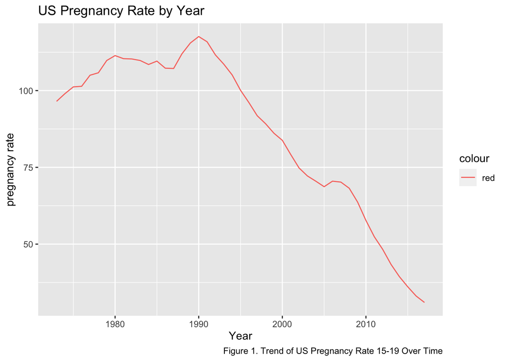

```r
library(ggplot2)
ggplot(data=p2US, aes(x=year, y=pregnancyrate1519, color = "red")) +
  geom_line()+
  labs(x = "Year", y = "pregnancy rate", title = "US Pregnancy Rate by Year", caption = "Figure 1. Trend of US Pregnancy Rate 15-19 Over Time")
```

## Normality Tests

### Distribution of Pregnancyrate1519

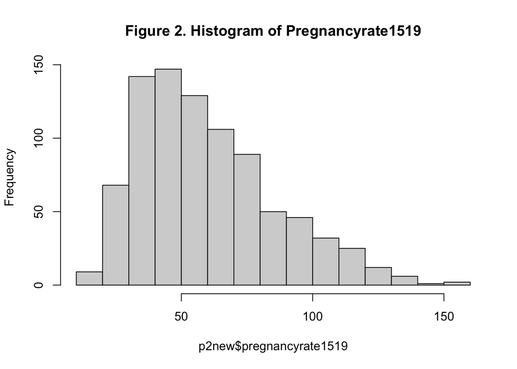

```r
hist(p2new$ pregnancyrate1519, main="Figure 2. Histogram of Pregnancyrate1519")
```

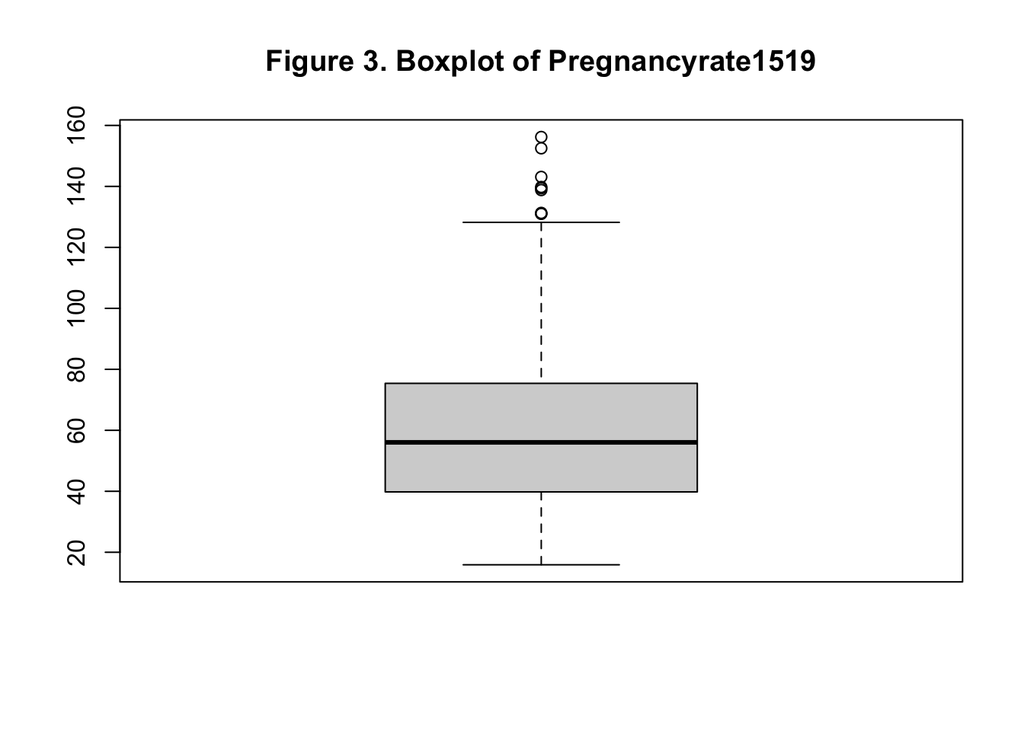

```r
boxplot(p2new$ pregnancyrate1519 , main="Figure 3. Boxplot of Pregnancyrate1519")
```

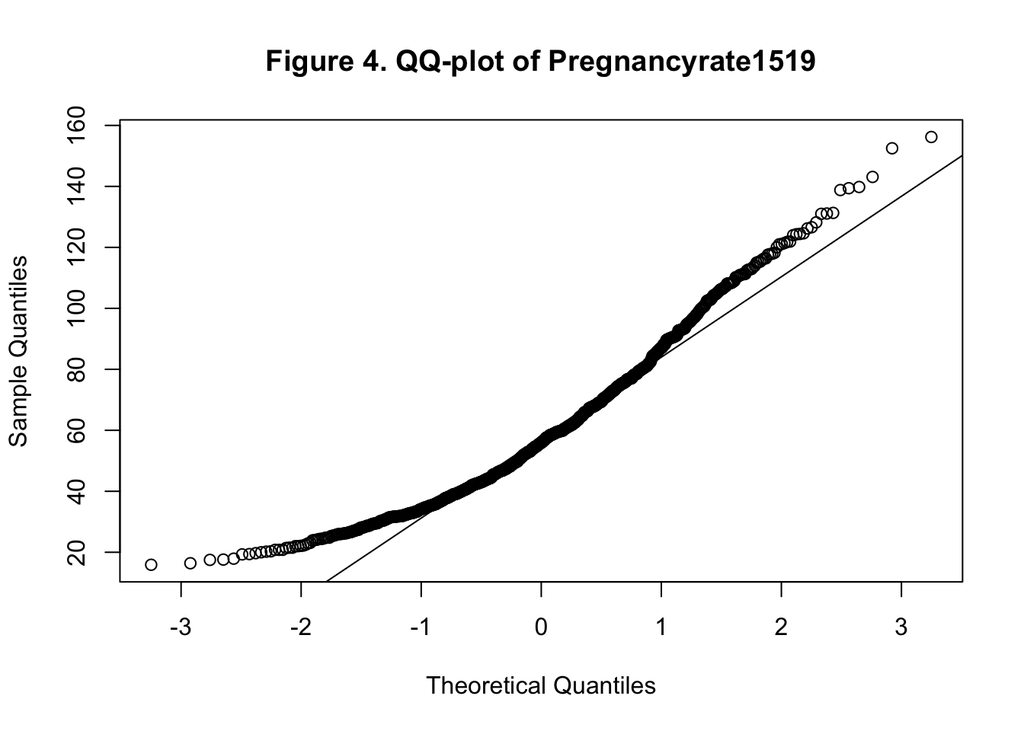

```r
qqnorm(p2new$ pregnancyrate1519 , main="Figure 4. QQ-plot of Pregnancyrate1519")
qqline(p2new$ pregnancyrate1519)
```

While we could remove all outliers to eliminate their influence, we need to consider why they are there in the first place. This could impact the validity of the results.

#### Pregnancy Rate Outliers

```r
newpregnancyrate1519= outlierKD2(p2new, pregnancyrate1519, rm=TRUE, boxplt=TRUE, histogram=TRUE, qqplt=TRUE)
outPR = subset(newpregnancyrate1519, is.na(pregnancyrate1519))
xkabledplyhead(outPR, title = " Table 2. Outliers for Pregnancy Rate")
```

[output not shown]

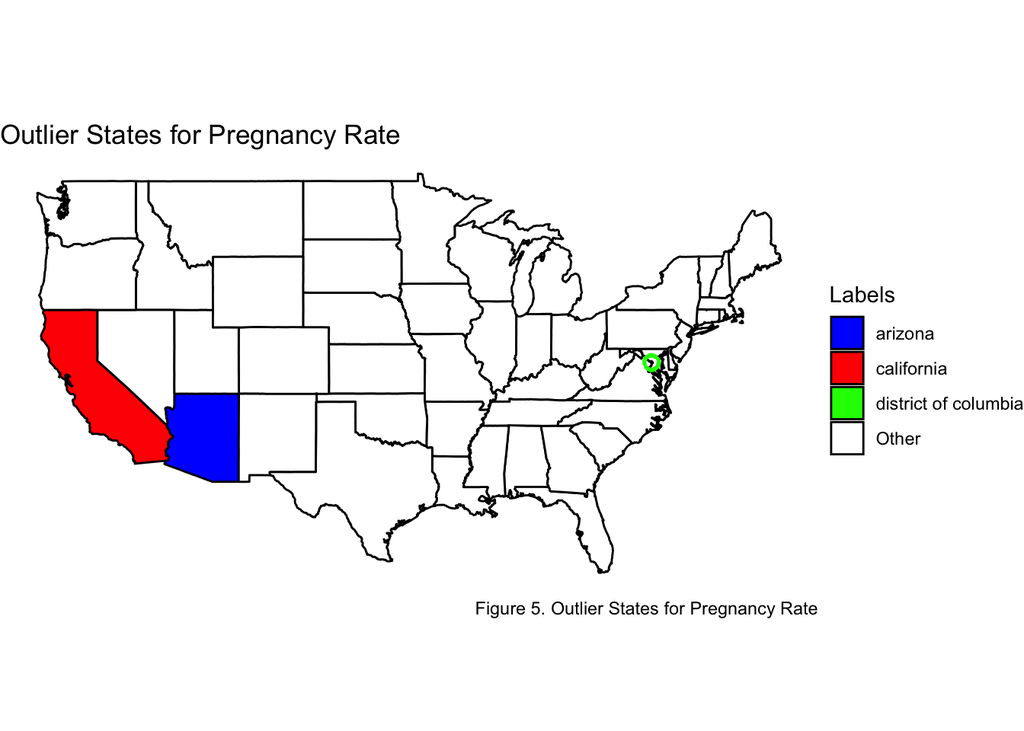

```r
library(maps)
library(ggplot2)

us_map <- map_data("state")

highlight_states <- c("california", "arizona", "district of columbia")

ggplot() +
  geom_polygon(data = us_map, aes(x = long, y = lat, group = group, fill = ifelse(region %in% highlight_states, region, "Other")),
               color = "black") +
  theme_void() +
  coord_map() +
  scale_fill_manual(values = c("california" = "red", "arizona" = "blue", "district of columbia" = "green", "Other" = "white"), name = "Labels") +
  labs(title = "Outlier States for Pregnancy Rate", caption = "Figure 5. Outlier States for Pregnancy Rate") +
  geom_point(data = us_map[us_map$region == "district of columbia", ], aes(x = long, y = lat), color = "green", size = 3, shape = 1)
```

When examining outliers, we found that the majority of these outliers occured in three states: California, Arizona, and District of Columbia (Figure 5). The data from the Guttmacher Institute shows these states exhibit substantially higher rates of teen pregnancy.

#### Pregnancy Rates Total - Important Observations by Select States

```r
model_birthrate_state<-lm(pregnancyratetotal~birthratetotal + state, data = p2newdf1519)
summary(model_birthrate_state)
```

```
##
## Call:
## lm(formula = pregnancyratetotal ~ birthratetotal + state, data = p2newdf1519)
##
## Residuals:
##    Min     1Q Median     3Q    Max
## -18.92  -2.19  -0.87   1.23  47.46
##
## Coefficients:
##                Estimate Std. Error t value Pr(>|t|)
## (Intercept)     -27.287      3.485   -7.83  1.5e-14 ***
## birthratetotal    1.752      0.043   40.75  < 2e-16 ***
## stateAL           4.966      1.653    3.00  0.00274 **
## stateAR           0.460      1.597    0.29  0.77325
## stateAZ           3.475      1.560    2.23  0.02617 *
## stateCA          18.616      1.598   11.65  < 2e-16 ***
## stateCO           7.209      1.643    4.39  1.3e-05 ***
## stateCT          20.727      1.779   11.65  < 2e-16 ***
## stateDC          33.678      1.782   18.90  < 2e-16 ***
## stateDE          18.495      1.654   11.18  < 2e-16 ***
## stateFL          18.440      1.671   11.03  < 2e-16 ***
## stateGA           9.838      1.619    6.08  1.9e-09 ***
## stateHI          12.015      1.569    7.66  5.3e-14 ***
## stateIA           1.379      1.616    0.85  0.39380
## stateID          -5.106      1.552   -3.29  0.00105 **
## stateIL          11.951      1.639    7.29  7.3e-13 ***
## stateIN           2.165      1.626    1.33  0.18349
## stateKS          -1.865      1.573   -1.19  0.23585
## stateKY          -0.422      1.636   -0.26  0.79668
## stateLA           3.010      1.595    1.89  0.05953 .
## stateMA          18.302      1.812   10.10  < 2e-16 ***
## stateMD          21.824      1.671   13.06  < 2e-16 ***
## stateME           9.477      1.826    5.19  2.6e-07 ***
## stateMI          13.302      1.692    7.86  1.2e-14 ***
## stateMN           3.539      1.622    2.18  0.02940 *
## stateMO           4.164      1.630    2.55  0.01083 *
## stateMS           2.426      1.596    1.52  0.12884
## stateMT           2.953      1.624    1.82  0.06947 .
## stateNC           9.304      1.656    5.62  2.6e-08 ***
## stateND          -3.308      1.577   -2.10  0.03626 *
```

[output cut: 13 more lines]

```
## stateTN           5.233      1.655    3.16  0.00162 **
## stateTX           3.384      1.557    2.17  0.03004 *
## stateUT         -13.358      1.599   -8.36  2.8e-16 ***
## stateVA          13.012      1.670    7.79  2.0e-14 ***
## stateVT          13.532      1.877    7.21  1.3e-12 ***
## stateWA          11.486      1.648    6.97  6.6e-12 ***
## stateWI           3.127      1.675    1.87  0.06221 .
## stateWV           4.056      1.731    2.34  0.01938 *
## stateWY           0.793      1.585    0.50  0.61717
## ---
## Signif. codes:  0 '***' 0.001 '**' 0.01 '*' 0.05 '.' 0.1 ' ' 1
##
## Residual standard error: 4.52 on 815 degrees of freedom
## Multiple R-squared:  0.854,  Adjusted R-squared:  0.845
## F-statistic: 93.7 on 51 and 815 DF,  p-value: <2e-16
```

#### Pregnancies Over Years in States

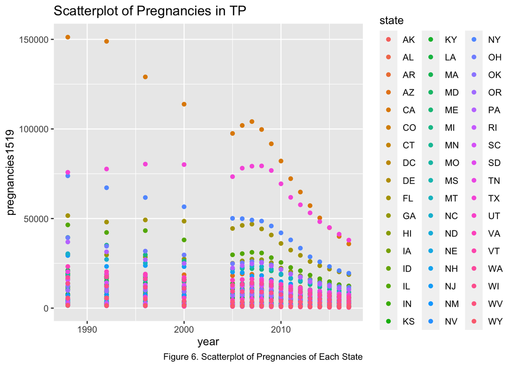

```r
library(ggplot2)
ggplot(data=p2new)+
  geom_point(mapping = aes(x=year, y=pregnancies1519, color=state))+
  labs(title = "Scatterplot of Pregnancies in TP", caption = "Figure 6. Scatterplot of Pregnancies of Each State")
```

## Abstinence Scales

We further analyzed the correlation between the presence of an abstinence education in school curricula for each state and their respective pregnancy rates.

### Pregnancy Rate by State Accounting for Abstinence Education

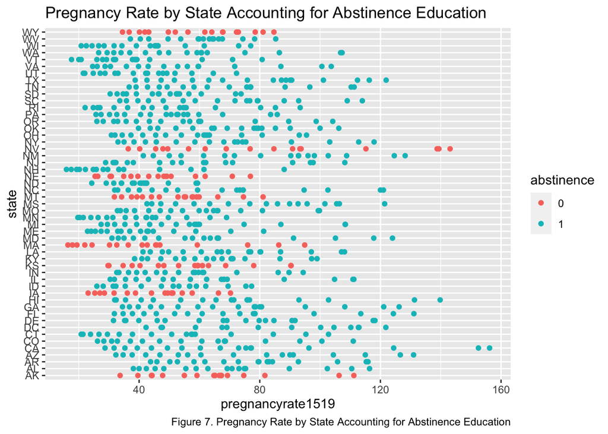

```r
library(ggplot2)
ggplot(data=p2new)+
  geom_point(mapping = aes(x=pregnancyrate1519, y=state, color=abstinence))+
  labs(title = "Pregnancy Rate by State Accounting for Abstinence Education", caption = "Figure 7. Pregnancy Rate by State Accounting for Abstinence Education")
```

Figure 7 shows a scatter plot of the state pregnancies of each state plotted against their corresponding abstinence scales, where a score of 0 represents the absence of any abstinence education laws and a score of 1 indicates the presence of requiring some degree of abstinence to be taught in schools in that state. However, no clear patterns were observed in the plot, suggesting the need for further analysis of the effectiveness of sex education for teenagers.

### Comparing Cover Sex Education and Not Cover Sex Education

After we created the dichotomous variable indicating the presence of abstinence education in the curriculum, we tested disparities between those who resided in a state with a requirement for some sort of abstinence education and those who resided in a state with no such requirement.

```r
cover <- subset(p2new, abstinence==0)
str(cover)
notcover <- subset(p2new, abstinence==1)
str(notcover)
```

```r
sexedu1519 = t.test(cover$pregnancyrate1519, notcover$pregnancies1519, conf.level=0.95)
sexedu1519
```

```
##
##  Welch Two Sample t-test
##
## data:  cover$pregnancyrate1519 and notcover$pregnancies1519
## t = -21, df = 727, p-value <2e-16
## alternative hypothesis: true difference in means is not equal to 0
## 95 percent confidence interval:
##  -15416 -12738
## sample estimates:
## mean of x mean of y
##      55.9   14132.6
```

# Data Analysis

## Full Linear Regression Model

```r
model1 <- lm(pregnancyrate1519 ~ abstinence+ abortionban_anomaly+ abortionban_sex+ substance_poli+ abortionrate1519+ birthrate1519+  abortionratio1519+ pregnancies1519+ abortions1519+ births1519+ miscarriages1519+ population1519+ population1544+ abortionstotal+ birthstotal+ pregnancyratetotal+ birthratetotal+ abortionratetotal+ abortionratiototal+ miscarriagestotal+ pregnanciestotal, data = p2newdf1519)
summary(model1)
```

```
##
## Call:
## lm(formula = pregnancyrate1519 ~ abstinence + abortionban_anomaly +
##     abortionban_sex + substance_poli + abortionrate1519 + birthrate1519 +
##     abortionratio1519 + pregnancies1519 + abortions1519 + births1519 +
##     miscarriages1519 + population1519 + population1544 + abortionstotal +
##     birthstotal + pregnancyratetotal + birthratetotal + abortionratetotal +
##     abortionratiototal + miscarriagestotal + pregnanciestotal,
##     data = p2newdf1519)
##
## Residuals:
##     Min      1Q  Median      3Q     Max
## -0.1407 -0.0400 -0.0028  0.0407  0.1407
##
## Coefficients:
##                       Estimate Std. Error t value Pr(>|t|)
## (Intercept)           1.93e-02   3.97e-02    0.49    0.627
## abstinence1          -9.22e-04   5.86e-03   -0.16    0.875
## abortionban_anomaly1  6.32e-03   6.63e-03    0.95    0.341
## abortionban_sex1     -9.67e-03   5.15e-03   -1.88    0.061 .
## substance_poli1       2.02e-03   4.40e-03    0.46    0.646
## abortionrate1519      1.10e+00   7.41e-04 1482.89   <2e-16 ***
## birthrate1519         1.20e+00   3.37e-04 3558.57   <2e-16 ***
## abortionratio1519     2.40e-05   2.26e-05    1.06    0.290
## pregnancies1519      -6.03e-04   4.46e-04   -1.35    0.177
## abortions1519         7.09e-04   4.89e-04    1.45    0.148
## births1519            8.18e-04   5.40e-04    1.51    0.130
## miscarriages1519     -4.65e-04   6.72e-04   -0.69    0.489
## population1519        8.40e-08   1.18e-07    0.71    0.478
## population1544        2.66e-08   3.07e-08    0.87    0.386
## abortionstotal       -1.10e-04   5.32e-04   -0.21    0.836
## birthstotal          -3.01e-05   5.88e-04   -0.05    0.959
## pregnancyratetotal    8.01e-02   3.65e-02    2.20    0.028 *
## birthratetotal       -9.66e-02   4.38e-02   -2.21    0.028 *
## abortionratetotal    -8.63e-02   4.04e-02   -2.14    0.033 *
## abortionratiototal   -1.58e-04   1.75e-04   -0.90    0.368
## miscarriagestotal    -1.01e-03   6.57e-04   -1.53    0.126
## pregnanciestotal      1.92e-04   4.83e-04    0.40    0.691
## ---
## Signif. codes:  0 '***' 0.001 '**' 0.01 '*' 0.05 '.' 0.1 ' ' 1
##
## Residual standard error: 0.0558 on 842 degrees of freedom
##   (3 observations deleted due to missingness)
## Multiple R-squared:     1,   Adjusted R-squared:     1
## F-statistic: 8.85e+06 on 21 and 842 DF,  p-value: <2e-16
```

We performed a linear regression model on the 15-19 age group, which included all available factors except for year and states. This is the “full model”. The coefficients column in the results table show the estimated effect of each predictor variable on the response variable, while holding all other predictors constant. For example, the coefficient for abortion rate among 15-19 year-olds is 1.1, indicating that for every one unit increase in the abortion rate per 1,000 females aged 15-19, the teen pregnancy rate is estimated to increase by 1.10 units, assuming all other variables remain constant. Similarly, the coefficient for birth rate in the linear regression model is 1.2, which means that for every one unit increase in the birth rate, the teen pregnancy rate is estimated to increase by 1.20 units, while all other factors are held constant.

Our analysis indicates that the abortion rate, birth rate, total pregnancy rate, birth rate total, and abortion rate total are significant variables that impact the teen pregnancy rate, as their p-values are less than 0.05. A p-value less than 0.05 indicates that there is evidence to reject the null hypothesis and that the corresponding variable has a statistically significant relationship with the teen pregnancy rate. Therefore, we can conclude that there is evidence to suggest that the abortion rate, birth rate, total pregnancy rate, total birth rate, and total abortion rate have a statistically significant relationship with the teen pregnancy rate in the population.

### Controlled Variables

#### Controlled by State

```r
model_state <- lm(pregnancyrate1519 ~ abstinence+ abortionban_anomaly+ abortionban_sex+ substance_poli+ abortionrate1519+ birthrate1519+  abortionratio1519+ pregnancies1519+ abortions1519+ births1519+ miscarriages1519+ population1519+ population1544+ abortionstotal+ birthstotal+ pregnancyratetotal+ birthratetotal+ abortionratetotal+ abortionratiototal+ miscarriagestotal+ pregnanciestotal + state, data = p2newdf1519)
summary(model_state)
```

```
##
## Call:
## lm(formula = pregnancyrate1519 ~ abstinence + abortionban_anomaly +
##     abortionban_sex + substance_poli + abortionrate1519 + birthrate1519 +
##     abortionratio1519 + pregnancies1519 + abortions1519 + births1519 +
##     miscarriages1519 + population1519 + population1544 + abortionstotal +
##     birthstotal + pregnancyratetotal + birthratetotal + abortionratetotal +
##     abortionratiototal + miscarriagestotal + pregnanciestotal +
##     state, data = p2newdf1519)
##
## Residuals:
##      Min       1Q   Median       3Q      Max
## -0.14581 -0.03864 -0.00138  0.03915  0.14794
##
## Coefficients: (4 not defined because of singularities)
##                       Estimate Std. Error t value Pr(>|t|)
## (Intercept)           8.51e-02   7.47e-02    1.14   0.2551
## abstinence1          -1.26e-02   2.38e-02   -0.53   0.5967
## abortionban_anomaly1  6.24e-02   3.32e-02    1.88   0.0610 .
## abortionban_sex1     -1.03e-01   4.97e-02   -2.07   0.0392 *
## substance_poli1      -2.06e-02   2.56e-02   -0.81   0.4198
## abortionrate1519      1.10e+00   1.03e-03 1063.88   <2e-16 ***
## birthrate1519         1.20e+00   4.77e-04 2515.92   <2e-16 ***
## abortionratio1519     1.55e-05   3.87e-05    0.40   0.6888
## pregnancies1519      -8.71e-04   4.51e-04   -1.93   0.0538 .
## abortions1519         1.01e-03   4.94e-04    2.04   0.0421 *
## births1519            1.14e-03   5.45e-04    2.10   0.0361 *
## miscarriages1519     -4.75e-04   6.87e-04   -0.69   0.4891
## population1519       -3.60e-08   1.38e-07   -0.26   0.7946
## population1544        1.41e-07   4.81e-08    2.94   0.0034 **
## abortionstotal       -1.08e-04   5.42e-04   -0.20   0.8422
## birthstotal          -4.85e-05   5.99e-04   -0.08   0.9355
## pregnancyratetotal    7.76e-02   3.69e-02    2.10   0.0360 *
## birthratetotal       -9.44e-02   4.43e-02   -2.13   0.0335 *
## abortionratetotal    -7.41e-02   4.10e-02   -1.81   0.0713 .
## abortionratiototal   -5.94e-04   3.10e-04   -1.92   0.0556 .
## miscarriagestotal    -7.80e-04   6.64e-04   -1.18   0.2400
## pregnanciestotal      1.69e-04   4.91e-04    0.34   0.7313
## stateAL              -1.18e-03   2.00e-02   -0.06   0.9531
## stateAR               1.37e-01   6.38e-02    2.15   0.0320 *
```

[output cut: 40 more lines]

```
## stateTX              -1.02e-01   9.20e-02   -1.11   0.2656
## stateUT               2.97e-02   2.98e-02    1.00   0.3186
## stateVA               2.82e-03   2.51e-02    0.11   0.9107
## stateVT               5.50e-03   2.49e-02    0.22   0.8253
## stateWA              -2.54e-02   2.19e-02   -1.16   0.2478
## stateWI                     NA         NA      NA       NA
## stateWV                     NA         NA      NA       NA
## stateWY               3.66e-03   2.02e-02    0.18   0.8562
## ---
## Signif. codes:  0 '***' 0.001 '**' 0.01 '*' 0.05 '.' 0.1 ' ' 1
##
## Residual standard error: 0.0552 on 796 degrees of freedom
##   (3 observations deleted due to missingness)
## Multiple R-squared:     1,   Adjusted R-squared:     1
## F-statistic: 2.83e+06 on 67 and 796 DF,  p-value: <2e-16
```

Based on the linear regression model with controlled state for 15 to 19 year old teens, the coefficient for state represents the change in pregnancy rate for a one-unit increase in the “state” variable. For example, the estimated coefficient for the state Arizona (AZ) is 0.132, which means that a one-unit increase in Arizona is associated with a 0.132 increase in pregnancy rate.

The analysis also shows that there are several significant variables that impact the teen pregnancy rate, including abortionban_sex1, abortionrate1519, birthrate1519, abortions1519, births1519, population1544, pregnancyratetotal, birthratetotal, stateAR, stateAZ, stateKS, stateKY, and stateOK. These variables have p-values less than 0.05, indicating evidence to suggest a statistically significant relationship with the teen pregnancy rate in the population when controlling for the state variable. We can conclude that these variables play an important role in predicting the teen pregnancy rate. It is important to note that the model has singularities since there are four NAs.

#### Controlled by Region

```r
model_region <- lm(pregnancyrate1519 ~ abstinence+ abortionban_anomaly+ abortionban_sex+ substance_poli+ abortionrate1519+ birthrate1519+  abortionratio1519+ pregnancies1519+ abortions1519+ births1519+ miscarriages1519+ population1519+ population1544+ abortionstotal+ birthstotal+ pregnancyratetotal+ birthratetotal+ abortionratetotal+ abortionratiototal+ miscarriagestotal+ pregnanciestotal + region, data = p2newdf1519)
summary(model_region)
```

```
##
## Call:
## lm(formula = pregnancyrate1519 ~ abstinence + abortionban_anomaly +
##     abortionban_sex + substance_poli + abortionrate1519 + birthrate1519 +
##     abortionratio1519 + pregnancies1519 + abortions1519 + births1519 +
##     miscarriages1519 + population1519 + population1544 + abortionstotal +
##     birthstotal + pregnancyratetotal + birthratetotal + abortionratetotal +
##     abortionratiototal + miscarriagestotal + pregnanciestotal +
##     region, data = p2newdf1519)
##
## Residuals:
##      Min       1Q   Median       3Q      Max
## -0.13812 -0.04006 -0.00224  0.04085  0.14097
##
## Coefficients:
##                       Estimate Std. Error t value Pr(>|t|)
## (Intercept)          -1.49e-02   4.52e-02   -0.33    0.742
## abstinence1          -8.12e-04   6.40e-03   -0.13    0.899
## abortionban_anomaly1  4.83e-03   7.12e-03    0.68    0.498
## abortionban_sex1     -9.99e-03   5.49e-03   -1.82    0.069 .
## substance_poli1      -5.06e-04   4.93e-03   -0.10    0.918
## abortionrate1519      1.10e+00   7.88e-04 1394.50   <2e-16 ***
## birthrate1519         1.20e+00   3.66e-04 3281.64   <2e-16 ***
## abortionratio1519     2.18e-05   2.42e-05    0.90    0.368
## pregnancies1519      -6.56e-04   4.47e-04   -1.47    0.142
## abortions1519         7.64e-04   4.90e-04    1.56    0.119
## births1519            8.76e-04   5.41e-04    1.62    0.106
## miscarriages1519     -4.35e-04   6.73e-04   -0.65    0.518
## population1519        9.67e-08   1.21e-07    0.80    0.423
## population1544        2.16e-08   3.22e-08    0.67    0.503
## abortionstotal       -1.24e-04   5.32e-04   -0.23    0.816
## birthstotal          -5.04e-05   5.89e-04   -0.09    0.932
## pregnancyratetotal    7.90e-02   3.66e-02    2.16    0.031 *
## birthratetotal       -9.49e-02   4.38e-02   -2.17    0.031 *
## abortionratetotal    -8.61e-02   4.05e-02   -2.13    0.034 *
## abortionratiototal   -6.31e-05   1.92e-04   -0.33    0.742
## miscarriagestotal    -9.46e-04   6.58e-04   -1.44    0.151
## pregnanciestotal      1.99e-04   4.83e-04    0.41    0.680
## regionmidwest         1.83e-02   1.17e-02    1.56    0.118
## regionnew_england     1.16e-02   9.88e-03    1.17    0.242
## regionsouth           2.03e-02   1.12e-02    1.81    0.071 .
## regionsouthwest       2.63e-02   1.34e-02    1.97    0.049 *
## regionwest            1.10e-02   1.06e-02    1.04    0.301
## ---
## Signif. codes:  0 '***' 0.001 '**' 0.01 '*' 0.05 '.' 0.1 ' ' 1
##
## Residual standard error: 0.0558 on 837 degrees of freedom
##   (3 observations deleted due to missingness)
## Multiple R-squared:     1,   Adjusted R-squared:     1
## F-statistic: 7.15e+06 on 26 and 837 DF,  p-value: <2e-16
```

As in the full model, our analysis confirms that the same five variables, abortion rate, birth rate, pregnancy rate total, birth rate total, and abortion rate total, significantly effect the teen pregnancy rate, as their p-values are less than 0.05. We can conclude that there is evidence to suggest that these five variables have a statistically significant relationship with the teen pregnancy rate in the population.

#### Controlled by Year

```r
p2newdf1519$year=as.factor(p2newdf1519$year)
model_year <- lm(pregnancyrate1519 ~ abstinence+ abortionban_anomaly+ abortionban_sex+ substance_poli+ abortionrate1519+ birthrate1519+  abortionratio1519+ pregnancies1519+ abortions1519+ births1519+ miscarriages1519+ population1519+ population1544+ abortionstotal+ birthstotal+ pregnancyratetotal+ birthratetotal+ abortionratetotal+ abortionratiototal+ miscarriagestotal+ pregnanciestotal+ year, data = p2newdf1519)
summary(model_year)
```

```
##
## Call:
## lm(formula = pregnancyrate1519 ~ abstinence + abortionban_anomaly +
##     abortionban_sex + substance_poli + abortionrate1519 + birthrate1519 +
##     abortionratio1519 + pregnancies1519 + abortions1519 + births1519 +
##     miscarriages1519 + population1519 + population1544 + abortionstotal +
##     birthstotal + pregnancyratetotal + birthratetotal + abortionratetotal +
##     abortionratiototal + miscarriagestotal + pregnanciestotal +
##     year, data = p2newdf1519)
##
## Residuals:
##      Min       1Q   Median       3Q      Max
## -0.13829 -0.03871 -0.00332  0.04043  0.15108
##
## Coefficients:
##                       Estimate Std. Error t value Pr(>|t|)
## (Intercept)          -1.13e-02   4.40e-02   -0.26    0.797
## abstinence1          -1.23e-03   5.92e-03   -0.21    0.836
## abortionban_anomaly1  7.39e-03   6.71e-03    1.10    0.271
## abortionban_sex1     -1.08e-02   5.23e-03   -2.06    0.040 *
## substance_poli1       2.36e-03   4.46e-03    0.53    0.596
## abortionrate1519      1.10e+00   9.26e-04 1186.85   <2e-16 ***
## birthrate1519         1.20e+00   3.88e-04 3094.62   <2e-16 ***
## abortionratio1519     3.62e-05   2.49e-05    1.46    0.146
## pregnancies1519      -6.01e-04   4.52e-04   -1.33    0.184
## abortions1519         6.97e-04   4.95e-04    1.41    0.160
## births1519            7.96e-04   5.47e-04    1.46    0.146
## miscarriages1519     -3.73e-04   6.80e-04   -0.55    0.583
## population1519        1.66e-07   1.34e-07    1.23    0.218
## population1544        1.08e-08   3.26e-08    0.33    0.740
## abortionstotal       -2.65e-04   5.39e-04   -0.49    0.623
## birthstotal          -1.97e-04   5.95e-04   -0.33    0.740
## pregnancyratetotal    7.73e-02   3.72e-02    2.08    0.038 *
## birthratetotal       -9.30e-02   4.46e-02   -2.09    0.037 *
## abortionratetotal    -8.39e-02   4.11e-02   -2.04    0.042 *
## abortionratiototal   -1.41e-04   1.79e-04   -0.79    0.430
## miscarriagestotal    -1.02e-03   6.66e-04   -1.53    0.127
## pregnanciestotal      3.33e-04   4.89e-04    0.68    0.496
## year1992              7.16e-03   1.27e-02    0.57    0.572
## year1996              4.54e-03   1.33e-02    0.34    0.732
## year2000              3.51e-03   1.41e-02    0.25    0.803
## year2005              7.22e-03   1.57e-02    0.46    0.645
## year2006              5.79e-03   1.59e-02    0.36    0.715
## year2007             -2.32e-03   1.60e-02   -0.15    0.885
## year2008              1.96e-03   1.61e-02    0.12    0.903
## year2009              4.17e-03   1.65e-02    0.25    0.801
## year2010              1.70e-02   1.68e-02    1.01    0.313
## year2011              1.84e-02   1.74e-02    1.06    0.289
## year2012              2.33e-02   1.81e-02    1.29    0.199
## year2013              1.42e-02   1.85e-02    0.77    0.442
## year2014              1.21e-02   1.91e-02    0.63    0.527
## year2015              5.34e-03   1.96e-02    0.27    0.785
## year2016              1.97e-02   1.97e-02    1.00    0.318
## year2017              2.40e-02   1.98e-02    1.21    0.225
## ---
## Signif. codes:  0 '***' 0.001 '**' 0.01 '*' 0.05 '.' 0.1 ' ' 1
##
## Residual standard error: 0.056 on 826 degrees of freedom
##   (3 observations deleted due to missingness)
## Multiple R-squared:     1,   Adjusted R-squared:     1
## F-statistic: 4.99e+06 on 37 and 826 DF,  p-value: <2e-16
```

We found that six variables have a statistically significant relationship with the teen pregnancy rate in the population, as their p-values are less than 0.05. These variables are abortionban_sex1, abortion rate, birth rate, pregnancy rate total, birth rate total, and abortion rate total. Therefore, we can conclude that there is evidence to suggest that these variables play a significant role in determining the teen pregnancy rate under control of years.

### Comparing Models

We used the anova test to compare the full model and the model that controls for state, region, and year to determine the best fit.

```r
anova(model1, model_state, model_region, model_year)
```

```
## Analysis of Variance Table
##
## Model 1: pregnancyrate1519 ~ abstinence + abortionban_anomaly + abortionban_sex +
##     substance_poli + abortionrate1519 + birthrate1519 + abortionratio1519 +
##     pregnancies1519 + abortions1519 + births1519 + miscarriages1519 +
##     population1519 + population1544 + abortionstotal + birthstotal +
##     pregnancyratetotal + birthratetotal + abortionratetotal +
##     abortionratiototal + miscarriagestotal + pregnanciestotal
## Model 2: pregnancyrate1519 ~ abstinence + abortionban_anomaly + abortionban_sex +
##     substance_poli + abortionrate1519 + birthrate1519 + abortionratio1519 +
##     pregnancies1519 + abortions1519 + births1519 + miscarriages1519 +
##     population1519 + population1544 + abortionstotal + birthstotal +
##     pregnancyratetotal + birthratetotal + abortionratetotal +
##     abortionratiototal + miscarriagestotal + pregnanciestotal +
##     state
## Model 3: pregnancyrate1519 ~ abstinence + abortionban_anomaly + abortionban_sex +
##     substance_poli + abortionrate1519 + birthrate1519 + abortionratio1519 +
##     pregnancies1519 + abortions1519 + births1519 + miscarriages1519 +
##     population1519 + population1544 + abortionstotal + birthstotal +
##     pregnancyratetotal + birthratetotal + abortionratetotal +
##     abortionratiototal + miscarriagestotal + pregnanciestotal +
##     region
## Model 4: pregnancyrate1519 ~ abstinence + abortionban_anomaly + abortionban_sex +
##     substance_poli + abortionrate1519 + birthrate1519 + abortionratio1519 +
##     pregnancies1519 + abortions1519 + births1519 + miscarriages1519 +
##     population1519 + population1544 + abortionstotal + birthstotal +
##     pregnancyratetotal + birthratetotal + abortionratetotal +
##     abortionratiototal + miscarriagestotal + pregnanciestotal +
##     year
##   Res.Df  RSS  Df Sum of Sq    F Pr(>F)
## 1    842 2.62
## 2    796 2.43  46    0.1956 1.40  0.045 *
## 3    837 2.60 -41   -0.1791 1.43  0.040 *
## 4    826 2.59  11    0.0176 0.52  0.888
## ---
## Signif. codes:  0 '***' 0.001 '**' 0.01 '*' 0.05 '.' 0.1 ' ' 1
```

## Feature/Variable Selection

### Stepwise

```r
stepwise_model <- step(model_region, direction = "both")
```

```
## Start:  AIC=-4961
## pregnancyrate1519 ~ abstinence + abortionban_anomaly + abortionban_sex +
##     substance_poli + abortionrate1519 + birthrate1519 + abortionratio1519 +
##     pregnancies1519 + abortions1519 + births1519 + miscarriages1519 +
##     population1519 + population1544 + abortionstotal + birthstotal +
##     pregnancyratetotal + birthratetotal + abortionratetotal +
##     abortionratiototal + miscarriagestotal + pregnanciestotal +
##     region
##
##                       Df Sum of Sq   RSS   AIC
## - region               5         0     3 -4965
## - birthstotal          1         0     3 -4963
## - substance_poli       1         0     3 -4963
## - abstinence           1         0     3 -4963
## - abortionstotal       1         0     3 -4963
## - abortionratiototal   1         0     3 -4963
## - pregnanciestotal     1         0     3 -4963
## - miscarriages1519     1         0     3 -4962
## - population1544       1         0     3 -4962
## - abortionban_anomaly  1         0     3 -4962
## - population1519       1         0     3 -4962
## - abortionratio1519    1         0     3 -4962
## <none>                                 3 -4961
## - miscarriagestotal    1         0     3 -4961
## - pregnancies1519      1         0     3 -4961
## - abortions1519        1         0     3 -4960
## - births1519           1         0     3 -4960
## - abortionban_sex      1         0     3 -4959
## - abortionratetotal    1         0     3 -4958
## - pregnancyratetotal   1         0     3 -4958
## - birthratetotal       1         0     3 -4958
## - abortionrate1519     1      6052  6055  1734
## - birthrate1519        1     33515 33518  3213
##
## Step:  AIC=-4965
## pregnancyrate1519 ~ abstinence + abortionban_anomaly + abortionban_sex +
##     substance_poli + abortionrate1519 + birthrate1519 + abortionratio1519 +
##     pregnancies1519 + abortions1519 + births1519 + miscarriages1519 +
##     population1519 + population1544 + abortionstotal + birthstotal +
##     pregnancyratetotal + birthratetotal + abortionratetotal +
```

[output cut: 359 more lines]

```
## + pregnancies1519      1         0      3 -4980
## + abortionratio1519    1         0      3 -4980
## - abortionban_sex      1         0      3 -4979
## + abortionratiototal   1         0      3 -4979
## + abortions1519        1         0      3 -4979
## + birthstotal          1         0      3 -4979
## + substance_poli       1         0      3 -4979
## + abstinence           1         0      3 -4979
## - population1544       1         0      3 -4979
## - pregnancyratetotal   1         0      3 -4978
## - abortionratetotal    1         0      3 -4978
## - birthratetotal       1         0      3 -4978
## + region               5         0      3 -4977
## - abortionrate1519     1     15936  15939  2538
## - birthrate1519        1    122783 122786  4303
```

```r
summary(stepwise_model)
```

```
##
## Call:
## lm(formula = pregnancyrate1519 ~ abortionban_sex + abortionrate1519 +
##     birthrate1519 + population1544 + abortionstotal + pregnancyratetotal +
##     birthratetotal + abortionratetotal + miscarriagestotal +
##     pregnanciestotal, data = p2newdf1519)
##
## Residuals:
##      Min       1Q   Median       3Q      Max
## -0.14153 -0.03983 -0.00233  0.04217  0.14292
##
## Coefficients:
##                     Estimate Std. Error t value Pr(>|t|)
## (Intercept)         3.84e-03   2.24e-02    0.17    0.864
## abortionban_sex1   -9.17e-03   4.83e-03   -1.90    0.058 .
## abortionrate1519    1.10e+00   4.85e-04 2268.76   <2e-16 ***
## birthrate1519       1.20e+00   1.91e-04 6297.54   <2e-16 ***
## population1544      2.93e-08   1.42e-08    2.07    0.039 *
## abortionstotal     -8.44e-05   5.35e-05   -1.58    0.115
## pregnancyratetotal  7.81e-02   3.61e-02    2.16    0.031 *
## birthratetotal     -9.39e-02   4.34e-02   -2.16    0.031 *
## abortionratetotal  -8.59e-02   3.98e-02   -2.16    0.031 *
## miscarriagestotal  -1.02e-03   6.42e-04   -1.59    0.112
## pregnanciestotal    1.70e-04   1.07e-04    1.59    0.113
## ---
## Signif. codes:  0 '***' 0.001 '**' 0.01 '*' 0.05 '.' 0.1 ' ' 1
##
## Residual standard error: 0.0556 on 853 degrees of freedom
##   (3 observations deleted due to missingness)
## Multiple R-squared:     1,   Adjusted R-squared:     1
## F-statistic: 1.87e+07 on 10 and 853 DF,  p-value: <2e-16
```

Using stepwise variable selection, the significant variables, based on the p-values, are abortionrate1519, birthrate1519, population1544, pregnancyratetotal, birthratetotal, abortionratetotal.

### AIC

```r
forward_model <- step(model_region, direction = "forward")
```

```
## Start:  AIC=-4961
## pregnancyrate1519 ~ abstinence + abortionban_anomaly + abortionban_sex +
##     substance_poli + abortionrate1519 + birthrate1519 + abortionratio1519 +
##     pregnancies1519 + abortions1519 + births1519 + miscarriages1519 +
##     population1519 + population1544 + abortionstotal + birthstotal +
##     pregnancyratetotal + birthratetotal + abortionratetotal +
##     abortionratiototal + miscarriagestotal + pregnanciestotal +
##     region
```

```r
summary(forward_model)
```

```
##
## Call:
## lm(formula = pregnancyrate1519 ~ abstinence + abortionban_anomaly +
##     abortionban_sex + substance_poli + abortionrate1519 + birthrate1519 +
##     abortionratio1519 + pregnancies1519 + abortions1519 + births1519 +
##     miscarriages1519 + population1519 + population1544 + abortionstotal +
##     birthstotal + pregnancyratetotal + birthratetotal + abortionratetotal +
##     abortionratiototal + miscarriagestotal + pregnanciestotal +
##     region, data = p2newdf1519)
##
## Residuals:
##      Min       1Q   Median       3Q      Max
## -0.13812 -0.04006 -0.00224  0.04085  0.14097
##
## Coefficients:
##                       Estimate Std. Error t value Pr(>|t|)
## (Intercept)          -1.49e-02   4.52e-02   -0.33    0.742
## abstinence1          -8.12e-04   6.40e-03   -0.13    0.899
## abortionban_anomaly1  4.83e-03   7.12e-03    0.68    0.498
## abortionban_sex1     -9.99e-03   5.49e-03   -1.82    0.069 .
## substance_poli1      -5.06e-04   4.93e-03   -0.10    0.918
## abortionrate1519      1.10e+00   7.88e-04 1394.50   <2e-16 ***
## birthrate1519         1.20e+00   3.66e-04 3281.64   <2e-16 ***
## abortionratio1519     2.18e-05   2.42e-05    0.90    0.368
## pregnancies1519      -6.56e-04   4.47e-04   -1.47    0.142
## abortions1519         7.64e-04   4.90e-04    1.56    0.119
## births1519            8.76e-04   5.41e-04    1.62    0.106
## miscarriages1519     -4.35e-04   6.73e-04   -0.65    0.518
## population1519        9.67e-08   1.21e-07    0.80    0.423
## population1544        2.16e-08   3.22e-08    0.67    0.503
## abortionstotal       -1.24e-04   5.32e-04   -0.23    0.816
## birthstotal          -5.04e-05   5.89e-04   -0.09    0.932
## pregnancyratetotal    7.90e-02   3.66e-02    2.16    0.031 *
## birthratetotal       -9.49e-02   4.38e-02   -2.17    0.031 *
## abortionratetotal    -8.61e-02   4.05e-02   -2.13    0.034 *
## abortionratiototal   -6.31e-05   1.92e-04   -0.33    0.742
## miscarriagestotal    -9.46e-04   6.58e-04   -1.44    0.151
## pregnanciestotal      1.99e-04   4.83e-04    0.41    0.680
## regionmidwest         1.83e-02   1.17e-02    1.56    0.118
## regionnew_england     1.16e-02   9.88e-03    1.17    0.242
## regionsouth           2.03e-02   1.12e-02    1.81    0.071 .
## regionsouthwest       2.63e-02   1.34e-02    1.97    0.049 *
## regionwest            1.10e-02   1.06e-02    1.04    0.301
## ---
## Signif. codes:  0 '***' 0.001 '**' 0.01 '*' 0.05 '.' 0.1 ' ' 1
##
## Residual standard error: 0.0558 on 837 degrees of freedom
##   (3 observations deleted due to missingness)
## Multiple R-squared:     1,   Adjusted R-squared:     1
## F-statistic: 7.15e+06 on 26 and 837 DF,  p-value: <2e-16
```

Using Akaike Information Criterion (AIC), the significant variables are abortionrate1519, birthrate1519, pregnancyratetotal, birthratetotal, abortionratetotal, and regionsouthwest. These variables have a significant effect on the teenage pregnancy rate. We found the AIC to be -4961, which indicates a very good fit of the model.

```r
backward_model <- step(model_region, direction = "backward")
```

```
## Start:  AIC=-4961
## pregnancyrate1519 ~ abstinence + abortionban_anomaly + abortionban_sex +
##     substance_poli + abortionrate1519 + birthrate1519 + abortionratio1519 +
##     pregnancies1519 + abortions1519 + births1519 + miscarriages1519 +
##     population1519 + population1544 + abortionstotal + birthstotal +
##     pregnancyratetotal + birthratetotal + abortionratetotal +
##     abortionratiototal + miscarriagestotal + pregnanciestotal +
##     region
##
##                       Df Sum of Sq   RSS   AIC
## - region               5         0     3 -4965
## - birthstotal          1         0     3 -4963
## - substance_poli       1         0     3 -4963
## - abstinence           1         0     3 -4963
## - abortionstotal       1         0     3 -4963
## - abortionratiototal   1         0     3 -4963
## - pregnanciestotal     1         0     3 -4963
## - miscarriages1519     1         0     3 -4962
## - population1544       1         0     3 -4962
## - abortionban_anomaly  1         0     3 -4962
## - population1519       1         0     3 -4962
## - abortionratio1519    1         0     3 -4962
## <none>                                 3 -4961
## - miscarriagestotal    1         0     3 -4961
## - pregnancies1519      1         0     3 -4961
## - abortions1519        1         0     3 -4960
## - births1519           1         0     3 -4960
## - abortionban_sex      1         0     3 -4959
## - abortionratetotal    1         0     3 -4958
## - pregnancyratetotal   1         0     3 -4958
## - birthratetotal       1         0     3 -4958
## - abortionrate1519     1      6052  6055  1734
## - birthrate1519        1     33515 33518  3213
##
## Step:  AIC=-4965
## pregnancyrate1519 ~ abstinence + abortionban_anomaly + abortionban_sex +
##     substance_poli + abortionrate1519 + birthrate1519 + abortionratio1519 +
##     pregnancies1519 + abortions1519 + births1519 + miscarriages1519 +
##     population1519 + population1544 + abortionstotal + birthstotal +
##     pregnancyratetotal + birthratetotal + abortionratetotal +
```

[output cut: 281 more lines]

```
##     population1544 + abortionstotal + pregnancyratetotal + birthratetotal +
##     abortionratetotal + miscarriagestotal + pregnanciestotal
##
##                      Df Sum of Sq    RSS   AIC
## <none>                                 3 -4981
## - abortionstotal      1         0      3 -4980
## - pregnanciestotal    1         0      3 -4980
## - miscarriagestotal   1         0      3 -4980
## - abortionban_sex     1         0      3 -4979
## - population1544      1         0      3 -4979
## - pregnancyratetotal  1         0      3 -4978
## - abortionratetotal   1         0      3 -4978
## - birthratetotal      1         0      3 -4978
## - abortionrate1519    1     15936  15939  2538
## - birthrate1519       1    122783 122786  4303
```

```r
summary(backward_model)
```

```
##
## Call:
## lm(formula = pregnancyrate1519 ~ abortionban_sex + abortionrate1519 +
##     birthrate1519 + population1544 + abortionstotal + pregnancyratetotal +
##     birthratetotal + abortionratetotal + miscarriagestotal +
##     pregnanciestotal, data = p2newdf1519)
##
## Residuals:
##      Min       1Q   Median       3Q      Max
## -0.14153 -0.03983 -0.00233  0.04217  0.14292
##
## Coefficients:
##                     Estimate Std. Error t value Pr(>|t|)
## (Intercept)         3.84e-03   2.24e-02    0.17    0.864
## abortionban_sex1   -9.17e-03   4.83e-03   -1.90    0.058 .
## abortionrate1519    1.10e+00   4.85e-04 2268.76   <2e-16 ***
## birthrate1519       1.20e+00   1.91e-04 6297.54   <2e-16 ***
## population1544      2.93e-08   1.42e-08    2.07    0.039 *
## abortionstotal     -8.44e-05   5.35e-05   -1.58    0.115
## pregnancyratetotal  7.81e-02   3.61e-02    2.16    0.031 *
## birthratetotal     -9.39e-02   4.34e-02   -2.16    0.031 *
## abortionratetotal  -8.59e-02   3.98e-02   -2.16    0.031 *
## miscarriagestotal  -1.02e-03   6.42e-04   -1.59    0.112
## pregnanciestotal    1.70e-04   1.07e-04    1.59    0.113
## ---
## Signif. codes:  0 '***' 0.001 '**' 0.01 '*' 0.05 '.' 0.1 ' ' 1
##
## Residual standard error: 0.0556 on 853 degrees of freedom
##   (3 observations deleted due to missingness)
## Multiple R-squared:     1,   Adjusted R-squared:     1
## F-statistic: 1.87e+07 on 10 and 853 DF,  p-value: <2e-16
```

## Reduced Model

```r
model2 <- lm(pregnancyrate1519 ~ abortionrate1519+ birthrate1519+ pregnancyratetotal+ birthratetotal+ abortionratetotal, data = p2newdf1519)
summary(model2)
```

```
##
## Call:
## lm(formula = pregnancyrate1519 ~ abortionrate1519 + birthrate1519 +
##     pregnancyratetotal + birthratetotal + abortionratetotal,
##     data = p2newdf1519)
##
## Residuals:
##      Min       1Q   Median       3Q      Max
## -0.14991 -0.03963 -0.00267  0.04126  0.14697
##
## Coefficients:
##                     Estimate Std. Error t value Pr(>|t|)
## (Intercept)         0.018069   0.019410    0.93    0.352
## abortionrate1519    1.099472   0.000453 2425.33   <2e-16 ***
## birthrate1519       1.200352   0.000172 6964.98   <2e-16 ***
## pregnancyratetotal  0.072934   0.036217    2.01    0.044 *
## birthratetotal     -0.087948   0.043455   -2.02    0.043 *
## abortionratetotal  -0.079860   0.039837   -2.00    0.045 *
## ---
## Signif. codes:  0 '***' 0.001 '**' 0.01 '*' 0.05 '.' 0.1 ' ' 1
##
## Residual standard error: 0.0558 on 858 degrees of freedom
##   (3 observations deleted due to missingness)
## Multiple R-squared:     1,   Adjusted R-squared:     1
## F-statistic: 3.71e+07 on 5 and 858 DF,  p-value: <2e-16
```

Subsequently, we created a reduced model by including only the five variables (abortionrate1519, birthrate1519, pregnancyratetotal, birthratetotal, abortionratetotal) that were found to be significant in the model controlled by region (model_region). Our analysis of this model revealed all variables remained statistically significant. Therefore, we can conclude that there is evidence to suggest these variables play a significant role in determining the teen pregnancy rate.

Based on the results, it appears that only the abortionrate1519, birthrate1519, pregnancyratetotal, birthratetotal, abortionratetotal are significantly associated with pregnancy rates among 15 to 19 year old teens. The other variables we included, such as abstinence, abortionban_anomaly, abortionban_sex, substance_poli, and miscarriage would not affect pregnancy rates for teenagers.

### Compare Controlled by Region to Reduced Model

```r
aov2region <- anova(model2, model_region)
aov2region
```

```
## Analysis of Variance Table
##
## Model 1: pregnancyrate1519 ~ abortionrate1519 + birthrate1519 + pregnancyratetotal +
##     birthratetotal + abortionratetotal
## Model 2: pregnancyrate1519 ~ abstinence + abortionban_anomaly + abortionban_sex +
##     substance_poli + abortionrate1519 + birthrate1519 + abortionratio1519 +
##     pregnancies1519 + abortions1519 + births1519 + miscarriages1519 +
##     population1519 + population1544 + abortionstotal + birthstotal +
##     pregnancyratetotal + birthratetotal + abortionratetotal +
##     abortionratiototal + miscarriagestotal + pregnanciestotal +
##     region
##   Res.Df  RSS Df Sum of Sq    F Pr(>F)
## 1    858 2.67
## 2    837 2.60 21      0.07 1.07   0.37
```

When comparing the controlled by region model to the reduced model, the obtained p-value is greater than the significance level of 0.05. This indicates that the model controlled by region (Model 2) does not provide a statistically significant improvement over the reduced model (Model 1). Moreover, the reduced model is more parsimonious and easier to interpret, and therefore may be a more appropriate choice. We conclude that the reduced model is better suited for this analysis. Therefore, further analysis would focus on reduced model to gain more insights.

#### Reduced Model with Variable Region

```r
model3 <- lm(pregnancyrate1519 ~ abortionrate1519+ birthrate1519+ pregnancyratetotal+ birthratetotal+ abortionratetotal+region, data = p2newdf1519)
summary(model3)
```

```
##
## Call:
## lm(formula = pregnancyrate1519 ~ abortionrate1519 + birthrate1519 +
##     pregnancyratetotal + birthratetotal + abortionratetotal +
##     region, data = p2newdf1519)
##
## Residuals:
##      Min       1Q   Median       3Q      Max
## -0.14988 -0.04053 -0.00313  0.04112  0.14922
##
## Coefficients:
##                     Estimate Std. Error t value Pr(>|t|)
## (Intercept)        -0.001077   0.025623   -0.04    0.966
## abortionrate1519    1.099468   0.000520 2112.72   <2e-16 ***
## birthrate1519       1.200205   0.000237 5072.75   <2e-16 ***
## pregnancyratetotal  0.072919   0.036311    2.01    0.045 *
## birthratetotal     -0.087850   0.043567   -2.02    0.044 *
## abortionratetotal  -0.079396   0.039934   -1.99    0.047 *
## regionmidwest       0.015458   0.009069    1.70    0.089 .
## regionnew_england   0.011727   0.009135    1.28    0.200
## regionsouth         0.016656   0.009171    1.82    0.070 .
## regionsouthwest     0.015469   0.011469    1.35    0.178
## regionwest          0.010522   0.008579    1.23    0.220
## ---
## Signif. codes:  0 '***' 0.001 '**' 0.01 '*' 0.05 '.' 0.1 ' ' 1
##
## Residual standard error: 0.0559 on 853 degrees of freedom
##   (3 observations deleted due to missingness)
## Multiple R-squared:     1,   Adjusted R-squared:     1
## F-statistic: 1.85e+07 on 10 and 853 DF,  p-value: <2e-16
```

In the AIC model, there is an additional variable, region, which is significant. Thus, we formed a model that added on a region varible to reduced model. However, the variables related to region are not statistically significant with p-values greater than 0.05. Therefore, it can be concluded that the region does not have a significant effect on the response variable.

##### Compare Reduced Model (Model 2) and Reduced Model with Region (Model 3)

```r
aov23 <- anova(model2, model3)
aov23
```

```
## Analysis of Variance Table
##
## Model 1: pregnancyrate1519 ~ abortionrate1519 + birthrate1519 + pregnancyratetotal +
##     birthratetotal + abortionratetotal
## Model 2: pregnancyrate1519 ~ abortionrate1519 + birthrate1519 + pregnancyratetotal +
##     birthratetotal + abortionratetotal + region
##   Res.Df  RSS Df Sum of Sq    F Pr(>F)
## 1    858 2.67
## 2    853 2.66  5    0.0119 0.76   0.58
```

We performed an ANOVA test to compare the reduced model alone and the reduced model with region. The resulting p-value for comparing the reduced model to the model with region is greater than the significance level of 0.05, indicating that the addition of region did not provide a statistically significant improvement over the reduced model. Given that information, the reduced model is the most appropriate model for this analysis. The final model equation is pregnancyrate1519 = 0.018069 + 1.099472(abortionrate1519) + 1.200352(birthrate1519) + 0.072934(pregnancyratetotal) - 0.087948(birthratetotal) - 0.079860(abortionratetotal)

## Model Diagnostics for Reduced Model

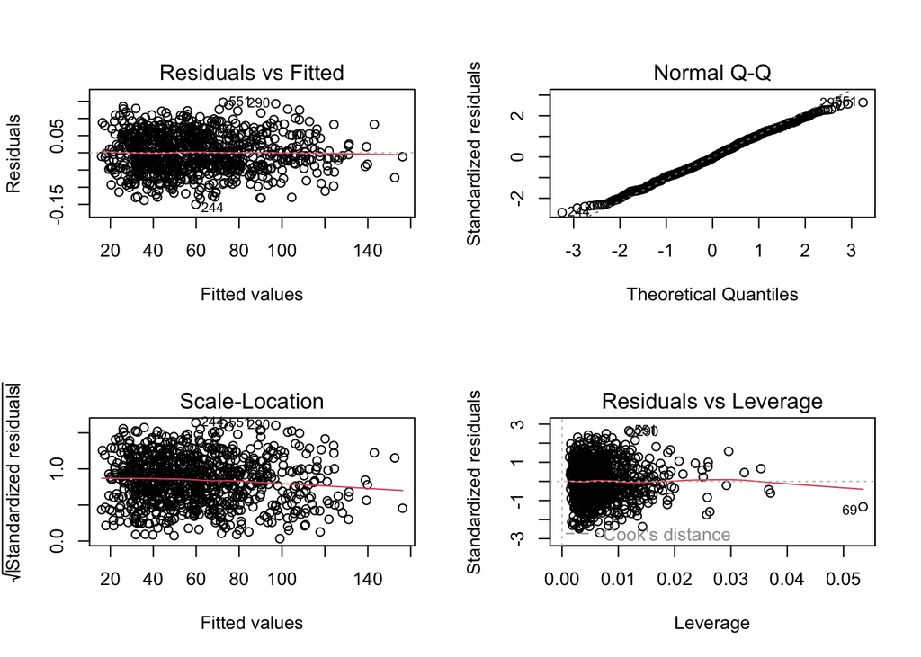

```r
par(mfrow=c(2,2))
plot(model2)
```

Figure 8. Model Diagnostics for Reduced Model

We performed model diagnostics (shown in figure 8) to evaluate whether the reduced model is a good fit for the data. The first step is to examine the residuals, which represent the difference between the predicted and actual values, for any patterns. We started by creating a residuals vs. fitted plot to check for non-linear relationships or heteroscedasticity. The plot indicated that the data met the regression assumptions well and there were no discernible patterns.

We checked the normal QQ-plot to see whether the residuals followed a normal distribution. The residuals followed a straight line, indicating that they met the normality assumption.

We then checked the Scale-Location plot to determine whether the variance of the residuals is constant across all values of the predictors. The plot showed that the residuals appeared randomly spread and we observed a horizontal line with equally (randomly) spread points, indicating that the model met the homoscedasticity assumption.

Lastly, we examined the residuals vs. leverage plot to identify influential observations, such as outliers or influential data points that may have a large effect on the model. The plot showed there were some outliers or influential data points, but including or excluding them did not significantly affect the results. Based on the results of the model diagnostics, we can conclude that the reduced model is a good fit for the data.

### Correlation

Next, we want to check correlation to see if there is any multicollinearity.

#### Correlation Matrices

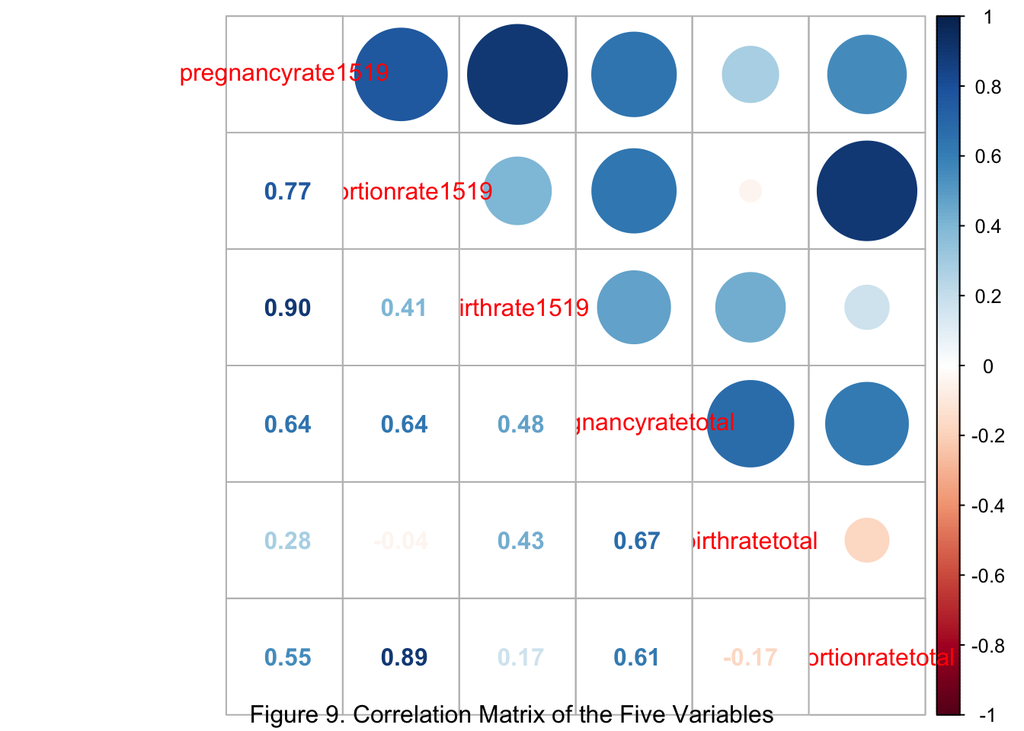

```r
library(corrplot)
signp2newdf1519 <- p2new[, c("pregnancyrate1519", "abortionrate1519", "birthrate1519", "pregnancyratetotal", "birthratetotal", "abortionratetotal")]
signp2newdf1519<-na.omit(signp2newdf1519)
corPearson = cor(signp2newdf1519)
corrplot.mixed(corPearson)
mtext("Figure 9. Correlation Matrix of the Five Variables", side=1, line=4)
```

Through the correlation matrix in figure 9, we found that pregnancy rate is highly correlated to birthrate1519, and abortionrate1519.

#### VIF

```r
library(faraway)
vif_values<- vif(model2)
formatted_vif <- format(vif_values, scientific = FALSE)
print(formatted_vif)
```

```
##   abortionrate1519      birthrate1519 pregnancyratetotal     birthratetotal
##         "    7.36"         "    1.87"         "44440.56"         "28509.15"
##  abortionratetotal
##         "25118.85"
```

We first examined the Variance Inflation Factors (VIFs) for the variables in our regression model. We found that the VIFs for pregnancyratetotal, birthratetotal, and abortionratetotal were all above 10, indicating significant multicollinearity between these variables. To address this issue, we decided to remove these highly correlated predictors from the model. Ultimately, we chose to build the model with only abortionrate1519 and birthrate1519 as predictors, as these variables showed lower VIFs and were less correlated with each other.

### Model 4

Model 4 included only the highest correlated variable, birthrate1519.

```r
model4 <- lm(pregnancyrate1519 ~ birthrate1519, data = p2newdf1519)
summary(model4)
```

```
##
## Call:
## lm(formula = pregnancyrate1519 ~ birthrate1519, data = p2newdf1519)
##
## Residuals:
##    Min     1Q Median     3Q    Max
## -16.90  -7.99  -2.75   4.23  57.92
##
## Coefficients:
##               Estimate Std. Error t value Pr(>|t|)
## (Intercept)     4.6559     1.0027    4.64    4e-06 ***
## birthrate1519   1.5399     0.0258   59.78   <2e-16 ***
## ---
## Signif. codes:  0 '***' 0.001 '**' 0.01 '*' 0.05 '.' 0.1 ' ' 1
##
## Residual standard error: 11.4 on 862 degrees of freedom
##   (3 observations deleted due to missingness)
## Multiple R-squared:  0.806,  Adjusted R-squared:  0.805
## F-statistic: 3.57e+03 on 1 and 862 DF,  p-value: <2e-16
```

## Model 5

Model 5 included both the highest correlated variable, birthrate1519, and the second highest correlated variable, abortionrate1519.

```r
model5 <- lm(pregnancyrate1519 ~ birthrate1519+abortionrate1519, data = p2newdf1519)
summary(model5)
```

```
##
## Call:
## lm(formula = pregnancyrate1519 ~ birthrate1519 + abortionrate1519,
##     data = p2newdf1519)
##
## Residuals:
##     Min      1Q  Median      3Q     Max
## -0.1426 -0.0397 -0.0014  0.0407  0.1468
##
## Coefficients:
##                   Estimate Std. Error t value Pr(>|t|)
## (Intercept)      -0.003076   0.004974   -0.62     0.54
## birthrate1519     1.200179   0.000138 8674.48   <2e-16 ***
## abortionrate1519  1.099792   0.000184 5991.98   <2e-16 ***
## ---
## Signif. codes:  0 '***' 0.001 '**' 0.01 '*' 0.05 '.' 0.1 ' ' 1
##
## Residual standard error: 0.056 on 861 degrees of freedom
##   (3 observations deleted due to missingness)
## Multiple R-squared:     1,   Adjusted R-squared:     1
## F-statistic: 9.24e+07 on 2 and 861 DF,  p-value: <2e-16
```

### Model 4 and 5 Comparsion

```r
aov45 <- anova(model4, model5)
aov45
```

```
## Analysis of Variance Table
##
## Model 1: pregnancyrate1519 ~ birthrate1519
## Model 2: pregnancyrate1519 ~ birthrate1519 + abortionrate1519
##   Res.Df    RSS Df Sum of Sq        F Pr(>F)
## 1    862 112422
## 2    861      3  1    112419 35903853 <2e-16 ***
## ---
## Signif. codes:  0 '***' 0.001 '**' 0.01 '*' 0.05 '.' 0.1 ' ' 1
```

We utilized two models to determine the best predictors for our analysis. Model 4 included only the highest correlated variable, birthrate1519, while Model 5 included both the highest correlated variable, birthrate1519, and the second highest correlated variable, abortionrate1519. We then compared the two models using an F-test, which resulted in a p-value below the significance level of 0.05. This indicates that the addition of abortionrate1519 to the model provides a statistically significant improvement over the model with only birthrate1519. Therefore, we can conclude that Model 5, which includes both birthrate1519 and abortionrate1519, is the best model out of all the models that were created for this analysis.

#### Model 6: Interaction

```r
model6 <- lm(pregnancyrate1519 ~ birthrate1519*abortionrate1519, data = p2newdf1519)
summary(model6)
```

```
##
## Call:
## lm(formula = pregnancyrate1519 ~ birthrate1519 * abortionrate1519,
##     data = p2newdf1519)
##
## Residuals:
##      Min       1Q   Median       3Q      Max
## -0.14349 -0.03933 -0.00027  0.04084  0.14728
##
## Coefficients:
##                                 Estimate Std. Error t value Pr(>|t|)
## (Intercept)                    -1.14e-02   8.73e-03   -1.30     0.19
## birthrate1519                   1.20e+00   2.34e-04 5137.96   <2e-16 ***
## abortionrate1519                1.10e+00   5.42e-04 2031.29   <2e-16 ***
## birthrate1519:abortionrate1519 -1.38e-05   1.19e-05   -1.16     0.25
## ---
## Signif. codes:  0 '***' 0.001 '**' 0.01 '*' 0.05 '.' 0.1 ' ' 1
##
## Residual standard error: 0.0559 on 860 degrees of freedom
##   (3 observations deleted due to missingness)
## Multiple R-squared:     1,   Adjusted R-squared:     1
## F-statistic: 6.16e+07 on 3 and 860 DF,  p-value: <2e-16
```

```r
aov56 <- anova(model5, model6)
aov56
```

```
## Analysis of Variance Table
##
## Model 1: pregnancyrate1519 ~ birthrate1519 + abortionrate1519
## Model 2: pregnancyrate1519 ~ birthrate1519 * abortionrate1519
##   Res.Df  RSS Df Sum of Sq    F Pr(>F)
## 1    861 2.70
## 2    860 2.69  1    0.0042 1.34   0.25
```

We created a model (model 6) that included the interaction term between birthrate1519 and abortionrate1519 to explore different combinations of variables. We compared the performance of model 5, with both variables minus the interaction term, to model 6 using an ANOVA test. The resulting p-value was greater than the significance level of 0.05, indicating that the model with the interaction term did not provide a statistically significant improvement over model 5. Therefore, we can conclude that model 5 is the most appropriate model for this analysis.

## Model Diagnostics for model 5

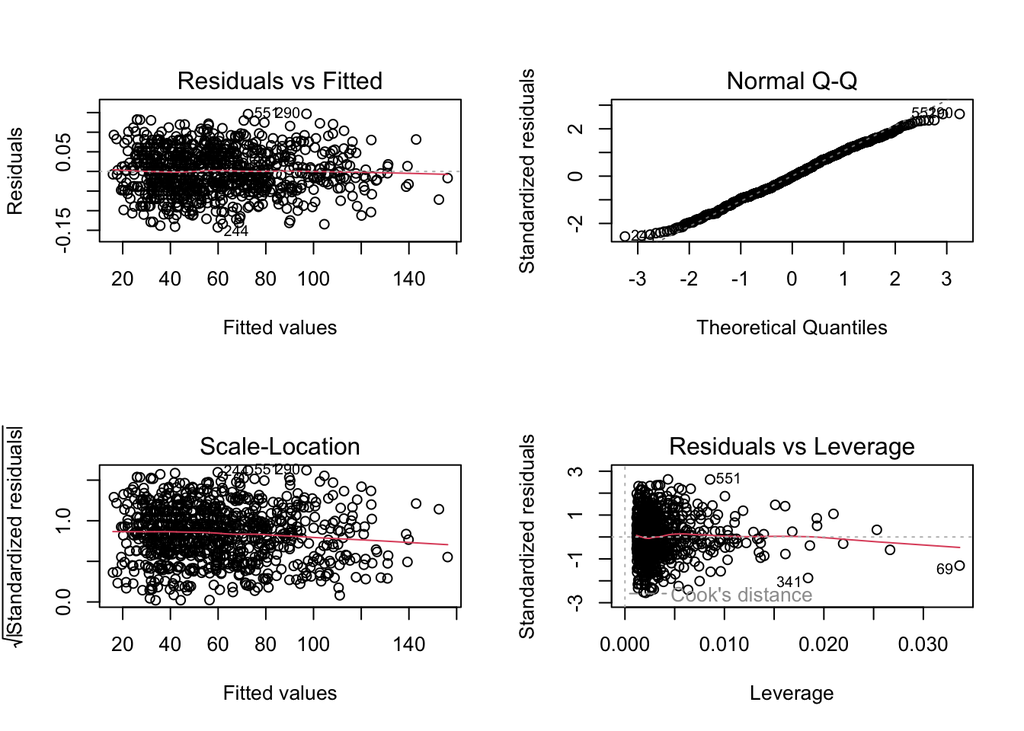

```r
par(mfrow=c(2,2))
plot(model5)
```

Figure 10. Model Diagnostics for Model 5

To evaluate the goodness-of-fit of model 5, we performed model diagnostics as shown in Figure 10. We first examined the residuals for any patterns by creating a residuals vs. fitted plot to check for non-linear relationships or heteroscedasticity. The plot indicated the data met the regression assumptions well and there were no discernible patterns. Next, we checked the normal QQ-plot to see whether the residuals followed a normal distribution. We found that the residuals followed a straight line, indicating that they met the normality assumption. We then checked the Scale-Location plot to determine whether the variance of the residuals is constant across all values of the predictors. The plot showed that the residuals appeared randomly spread, and we observed a horizontal line with equally (randomly) spread points, indicating that the model met the homoscedasticity assumption. Finally, we examined the residuals vs. leverage plot to identify influential observations, such as outliers or influential data points that may have a large effect on the model. The plot showed that there were some outliers or influential data points, but including or excluding them did not significantly affect the results. In addition, we detected through variance inflation factors (VIF) that there is no multicollinearity. Therefore, we can conclude that model 5, which consists of two variables, birthrate1519 and abortionrate1519, is valid, reliable, and can provide accurate predictions.

The model equation is: pregnancyrate1519 = -0.003076 + 1.200179 * birthrate1519 + 1.099792 * abortionrate1519. This equation shows that the predicted pregnancy rate for females aged 15-19 (pregnancyrate1519) can be estimated by adding -0.003076 to the product of 1.200179 and the birth rate for females aged 15-19 (birthrate1519), and adding 1.099792 times the abortion rate for females aged 15-19 (abortionrate1519). Both predictors are highly significant, with p-values <2e-16, indicating a strong linear relationship with the response variable.

## Regression Tree

```r
library(dplyr)
# define which columns to convert to categorical
cols_to_convert <- c('abstinence', 'abortionban_anomaly', 'abortionban_sex', 'substance_poli', 'year', 'state')
# convert specified columns to factors
p2 <- p2 %>%
  mutate_if(names(.) %in% cols_to_convert, as.factor)
str(p2)
```

```
## 'data.frame':    912 obs. of  43 variables:
##  $ X                  : int  0 1 2 3 4 5 6 7 8 9 ...
##  $ state              : Factor w/ 52 levels "AK","AL","AR",..: 2 2 2 2 2 2 2 2 2 2 ...
##  $ abstinence         : Factor w/ 3 levels "0","1","6": 2 2 2 2 2 2 2 2 2 2 ...
##  $ abortionban_anomaly: Factor w/ 3 levels "0","1","6": 1 1 1 1 1 1 1 1 1 1 ...
##  $ abortionban_sex    : Factor w/ 3 levels "0","1","6": 1 1 1 1 1 1 1 1 1 1 ...
##  $ substance_poli     : Factor w/ 3 levels "0","1","6": 2 2 2 2 2 2 2 2 2 2 ...
##  $ year               : Factor w/ 45 levels "1973","1974",..: 16 20 24 28 33 34 35 36 37 38 ...
##  $ pregnancyratelt15  : num  21.3 23.6 18.5 11.9 8.7 9.3 8.6 9.7 9 7.4 ...
##  $ pregnancyrate1519  : num  110.5 116.4 102.4 89.8 70.8 ...
##  $ pregnancyrate40plus: num  6.1 6.5 6.9 7.2 8.3 8.4 8.3 8.2 8.6 9.1 ...
##  $ abortionratelt15   : num  8.6 8.6 6 3.8 2.9 2.9 3.2 3.3 2.6 2.8 ...
##  $ abortionrate1519   : num  31.4 27.2 19.9 15.5 11.9 11.9 11.3 11.3 10.2 9.1 ...
##  $ abortionrate40plus : num  2.2 2.1 1.8 1.6 1.4 1.5 1.3 1.3 1.4 1.3 ...
##  $ birthratelt15      : num  9.9 11.7 9.9 6.4 4.6 5.1 4.2 5.1 5.1 3.6 ...
```

[output cut: 29 more lines]

```r
library(rpart)
library(rattle)
```

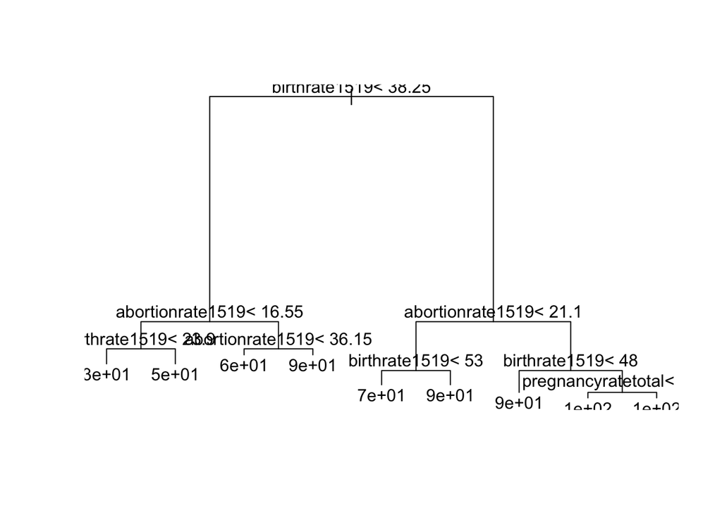

```r
# fit the classification tree
regtree1 <- rpart(pregnancyrate1519 ~ state + abstinence + abortionban_anomaly + abortionban_sex + substance_poli + year + abortionrate1519 + birthrate1519 + abortionratio1519 + pregnancies1519 + abortions1519 + births1519 + miscarriages1519 + population1519 + population1544 + abortionstotal + birthstotal + pregnancyratetotal + birthratetotal + abortionratetotal + abortionratiototal + miscarriagestotal + pregnanciestotal, data = p2, method = "anova")
# plot the tree
plot(regtree1)
text(regtree1)
```

[figure not shown]

```r
fancyRpartPlot(regtree1)
```

To identify determining factors on the pregnancy rate, we ran a regression tree. The results indicated that birthrate1519 and abortionrate1519 were determining factors on the pregnancy rate. We did not preform any type of control or pruning as we had small amount of observations

# Conclusion

Based on EDA, we can conclude that the US teen pregnancy rate has been declining since the 1990s. The pregnancy rate for teenagers aged 15 to 19 is slightly right-skewed because of the outliers in the data, particularly in California, Arizona, and the District of Columbia, which had substantially higher rates of teen pregnancy compared to other states. However, pregnancy rate can still considered to be normally distributed.

After conducting variable selection using stepwise, AIC, and BIC methods, we found that the significant variables in explaining the variation in teenage pregnancy rates were abortionrate1519, birthrate1519, pregnancyratetotal, birthratetotal, and abortionratetotal. These variables were also found to be significant in the model controlled by regions, indicating that they play a significant role in determining the teen pregnancy rate.

We created a reduced model including only five previously determined significant variables (abortionrate1519, birthrate1519, pregnancyratetotal, birthratetotal, abortionratetotal) which remained statistically significant. This suggests that these variables play a significant role in determining the teen pregnancy rate, while other variables such as abstinence, abortionban_anomaly, abortionban_sex, substance_poli, and miscarriage would not affect pregnancy rates for teenagers. We also performed model diagnostics with plots and found that the reduced model met the regression assumptions well and was a good fit for the data.

However, based on the analysis of the VIFs, we found that there was significant multicollinearity between the variables pregnancyratetotal, birthratetotal, and abortionratetotal. Since multicollinearity can lead to inaccurate and unreliable results in regression analysis, we removed these highly correlated predictors from the model. We decided to build the model (model 5) with only abortionrate1519 and birthrate1519 as predictors since they exhibited lower VIFs and were less correlated with each other. We found model 5 to be the best model out of the models created. In addition, model 5 met the regression assumptions which justifies our use of it for our regression analysis. This approach will likely lead to a more accurate and reliable regression model that can be used to answer our SMART question.

# Answer to SMART Question

Our SMART question is more about inference of the cause of the decrease in teen pregnancy rates from 1988 to 2017 by the state in the US. The model results suggests the variables abortion rate and birth rate are the main factors that contribute to the decrease in teen pregnancy rates observed between 1988 and 2017. These two variables appear to have a significant impact on teen pregnancy rates, indicating that higher abortion and birth rates among 15-19-year-olds are associated with higher teen pregnancy rates.

Other variables, such as abstinence, abortionban_anomaly, abortionban_sex, substance_poli, and miscarriage, are not significant predictors of teen pregnancy rates. This suggests that the decrease in teen pregnancy rates observed during the study period is not significantly explained by these variables.

Overall, the model’s findings suggest that strategies to address abortion and birth rates among 15- to 19-year-olds appear to have the greatest impact on teen pregnancy rates. These factors should be the primary focus of programs and policies designed to lower the number of teen pregnancies. However, it is essential to keep in mind that the assumptions and limitations of the study should be taken into account when interpreting the model results.

# Further Research

Although our analysis sheds some light on the factors that are responsible for the decline in the number of teen pregnancies in the United States, there are still a few limitations and potential areas for additional research. First, our review expects that the indicators remembered for the model are the main factors that impact adolescent pregnancy rates, which may not be the situation as a general rule. Teen pregnancy rates may also be influenced by peer influence, media exposure, and social and cultural attitudes toward sex and reproduction, among other things. Much of this data is sensitive health information and runs into ethical issues even if we were able to obtain it. Second, our concentrate just considers state-level information and may not catch the subtleties of youngster pregnancy rates at the nearby level. Teen pregnancy rates may be influenced by community-level factors like access to healthcare, education, and social support. Thirdly, our exploration just looks at adolescent pregnancy rates in the US and doesn’t consider contrasts between nations. Future investigation could examine how social, monetary, and methodology contrasts between countries could add to assortments in adolescent pregnancy rates. Last but not least, our study relies on the assumption that the relationships between the variables are linear, despite the possibility that this is not the case. To all the more likely appreciate the idea of the connection between the factors, future exploration could research nonlinear connections between the indicators and the reaction variable.

# References:

Centers for Disease Control and Prevention. (2022, February 17). Teen Birth Rates Data Visualization. National Center for Health Statistics. https://www.cdc.gov/nchs/data-visualization/teen-births/

Christen Jones, Z. (2022, Mar 28,). Florida governor ron DeSantis signs “parental rights in education” bill into law — known by critics as “don’t say gay” bill . CBS News, Retrieved from https://www.cbsnews.com/news/florida-desantis-dont-say-gay-bill-signed-parental-rights-in-education/

Darroch, J. E., Singh, S., & Frost, J. J. (2001). Differences in Teenage Pregnancy Rates among Five Developed Countries: The Roles of Sexual Activity and Contraceptive Use. Family Planning Perspectives, 33(6), 244–281. https://doi.org/10.2307/3030191

Historical income tables: Households. (2022 August 18). Table H-8: Median Household Income by State: 1984 to 2018. Bureau, U. S. C. Census.gov. https://www.census.gov/data/tables/time-series/demo/income-poverty/historical-income-households.html

National Center for Education Statistics. (2018). Table 203.20: High school graduates, by race/ethnicity and state or jurisdiction: 2015-16. In Digest of Education Statistics: 2017 (50th ed., pp. 148-149). U.S. Department of Education. https://nces.ed.gov/programs/digest/d17/tables/dt17_203.20.asp

Scally, G. (2002). Too much too young? teenage pregnancy is a public health, not a clinical, problem. International Journal of Epidemiology, 31(3), 554-555. doi:10.1093/ije/31.3.554 Sex ed state law and policy chart: SIECUS state profiles: July 2022(2022).

Sexuality Information and Education Council of the United States. (2020). SIECUS 2020 Sex Ed State Law and Policy Chart. https://siecus.org/wp-content/uploads/2020/05/SIECUS-2020-Sex-Ed-State-Law-and-Policy-Chart_May-2020-3.pdf

Stanger-Hall KF, Hall DW. Abstinence-only education and teen pregnancy rates: why we need comprehensive sex education in the U.S. PLoS One. 2011;6(10):e24658. doi: 10.1371/journal.pone.0024658. Epub 2011 Oct 14. PMID: 22022362; PMCID: PMC3194801.

Abortion bans in cases of sex or race selection or genetic anomaly (2023). Guttmacher Institute.

Maddow-Zimet, I., & Kost, K. (2021). Pregnancies, births and abortions in the united states, 1973–2017: National and state trends by age Guttmacher Institute.

Substance use during pregnancy (2023). Guttmacher Institute.

# Dataset Used

https://osf.io/kthnf/

# Methodology of Guttmacher Institute paper

https://www.guttmacher.org/sites/default/files/report_downloads/pregnancies-births-abortions-us-1973-2017-method-appendix.pdf